# S&P 500 ESG Data Pipeline and Crash-Risk Warning System

## 9 Coverage Checks

Basic coverage diagnostics: how many firms have price, EDGAR ESG, or snapshot ESG data in each year? These summaries feed the downstream usability audit and help spot data gaps before modeling.

```r
# ---- Yearly coverage: fraction of firms with each data type ----
coverage_by_year <- final_panel %>%
  group_by(year) %>%
  summarise(
    firms_total = n(),
    firms_with_price = sum(price_available, na.rm = TRUE),
    firms_with_edgar = sum(edgar_available, na.rm = TRUE),
    firms_with_snapshot = sum(snapshot_available, na.rm = TRUE),
    firms_with_price_and_edgar = sum(price_available & edgar_available, na.rm = TRUE),
    .groups = "drop"
  ) %>%
  mutate(
    price_coverage = round(firms_with_price / firms_total, 4),
    edgar_coverage = round(firms_with_edgar / firms_total, 4),
    snapshot_coverage = round(firms_with_snapshot / firms_total, 4)
  )

coverage_overview <- tibble(
  metric = c(
    "constituent_rows",
    "unique_cik",
    "years_in_panel",
    "panel_rows",
    "firms_with_any_price",
    "firms_with_any_edgar",
    "firms_with_snapshot_esg",
    "panel_start_year",
    "panel_end_year"
  ),
  value = c(
    nrow(company_master),
    n_distinct(company_master$cik),
    n_distinct(final_panel$year),
    nrow(final_panel),
    n_distinct(final_panel$symbol[final_panel$price_available]),
    n_distinct(final_panel$cik[final_panel$edgar_available]),
    sum(company_master$snapshot_available, na.rm = TRUE),
    START_YEAR,
    END_YEAR
  )
)

# ---- Company-level availability flags: which firms have data in any year? ----
company_coverage_flags <- final_panel %>%
  group_by(symbol, company_name, cik, gics_sector, gics_sub_industry) %>%
  summarise(
    any_price = any(price_available, na.rm = TRUE),
    any_edgar = any(edgar_available, na.rm = TRUE),
    snapshot_available = any(snapshot_available, na.rm = TRUE),
    first_price_year = if (any(price_available, na.rm = TRUE)) min(year[price_available], na.rm = TRUE) else NA_integer_,
    last_price_year = if (any(price_available, na.rm = TRUE)) max(year[price_available], na.rm = TRUE) else NA_integer_,
    first_edgar_year = if (any(edgar_available, na.rm = TRUE)) min(year[edgar_available], na.rm = TRUE) else NA_integer_,
    last_edgar_year = if (any(edgar_available, na.rm = TRUE)) max(year[edgar_available], na.rm = TRUE) else NA_integer_,
    .groups = "drop"
  )

data.table::fwrite(coverage_by_year, OUTPUT_FILES$coverage_year)
data.table::fwrite(coverage_overview, OUTPUT_FILES$coverage_overview)
data.table::fwrite(company_coverage_flags, OUTPUT_FILES$coverage_company)

coverage_overview %>% knitr::kable()
```

| metric | value |
| --- | --- |
| constituent_rows | 503 |
| unique_cik | 485 |
| years_in_panel | 12 |
| panel_rows | 6036 |
| firms_with_any_price | 477 |
| firms_with_any_edgar | 472 |
| firms_with_snapshot_esg | 430 |
| panel_start_year | 2012 |
| panel_end_year | 2023 |

```r
coverage_by_year %>% knitr::kable()
```

| year | firms_total | firms_with_price | firms_with_edgar | firms_with_snapshot | firms_with_price_and_edgar | price_coverage | edgar_coverage | snapshot_coverage |
| --- | --- | --- | --- | --- | --- | --- | --- | --- |
| 2012 | 503 | 440 | 42 | 430 | 42 | 0.8748 | 0.0835 | 0.8549 |
| 2013 | 503 | 448 | 77 | 430 | 76 | 0.8907 | 0.1531 | 0.8549 |
| 2014 | 503 | 453 | 129 | 430 | 127 | 0.9006 | 0.2565 | 0.8549 |
| 2015 | 503 | 458 | 180 | 430 | 178 | 0.9105 | 0.3579 | 0.8549 |
| 2016 | 503 | 462 | 231 | 430 | 228 | 0.9185 | 0.4592 | 0.8549 |
| 2017 | 503 | 464 | 294 | 430 | 290 | 0.9225 | 0.5845 | 0.8549 |
| 2018 | 503 | 466 | 353 | 430 | 350 | 0.9264 | 0.7018 | 0.8549 |
| 2019 | 503 | 470 | 404 | 430 | 400 | 0.9344 | 0.8032 | 0.8549 |
| 2020 | 503 | 473 | 441 | 430 | 437 | 0.9404 | 0.8767 | 0.8549 |
| 2021 | 503 | 473 | 455 | 430 | 450 | 0.9404 | 0.9046 | 0.8549 |
| 2022 | 503 | 475 | 466 | 430 | 461 | 0.9443 | 0.9264 | 0.8549 |
| 2023 | 503 | 477 | 471 | 430 | 465 | 0.9483 | 0.9364 | 0.8549 |

## 10 Output Files

```r
output_table <- tibble(
  file = to_project_relative(unname(c(unlist(OUTPUT_FILES), unlist(OUTPUT_USABILITY_FILES)))),
  description = c(
    "Current S&P 500 constituent master table with CIK, sector, and snapshot ESG",
    "Raw cached table of current S&P 500 constituents from Wikipedia",
    "Filtered daily price history for the S&P 500 universe",
    "Annual price features aggregated from daily prices",
    "Annual EDGAR ESG signal table aligned to the current S&P 500 universe",
    "Final annual price + ESG panel",
    "Coverage statistics by year",
    "Overall coverage overview",
    "Firm-level price/EDGAR coverage flags",
    "Dual-denominator usability overview",
    "Dual-denominator coverage by year",
    "Dual-denominator coverage by sector",
    "Field missingness summary for the main panel",
    "Coverage distribution by firm-level usability bucket",
    "Special sample and boundary-case summary",
    "Line chart of dual-denominator coverage by year",
    "Yearly bar chart for jointly available samples",
    "Sector coverage heatmap",
    "Field missingness bar chart",
    "Firm coverage bucket distribution"
  )
)

knitr::kable(output_table)
```

| file | description |
| --- | --- |
| data/derived/sp500_constituents_current.csv | Current S&P 500 constituent master table with CIK, sector, and snapshot ESG |
| data/derived/sp500_wiki_current.csv | Raw cached table of current S&P 500 constituents from Wikipedia |
| data/derived/sp500_price_daily_2011_2023.csv | Filtered daily price history for the S&P 500 universe |
| data/derived/sp500_price_annual_features_2012_2023.csv | Annual price features aggregated from daily prices |
| data/derived/sp500_edgar_esg_annual_2012_2023.csv | Annual EDGAR ESG signal table aligned to the current S&P 500 universe |
| data/derived/sp500_price_esg_panel_2012_2023.csv | Final annual price + ESG panel |
| output/sp500_coverage_by_year.csv | Coverage statistics by year |
| output/sp500_coverage_overview.csv | Overall coverage overview |
| output/sp500_company_coverage_flags.csv | Firm-level price/EDGAR coverage flags |
| output/01_data_usability/01_overview_dual_denominator.csv | Dual-denominator usability overview |
| output/01_data_usability/02_coverage_by_year_dual_denominator.csv | Dual-denominator coverage by year |
| output/01_data_usability/03_coverage_by_sector_dual_denominator.csv | Dual-denominator coverage by sector |
| output/01_data_usability/04_field_missingness.csv | Field missingness summary for the main panel |
| output/01_data_usability/05_company_coverage_buckets.csv | Coverage distribution by firm-level usability bucket |
| output/01_data_usability/06_special_cases_summary.csv | Special sample and boundary-case summary |
| output/01_data_usability/11_yearly_coverage_lines.png | Line chart of dual-denominator coverage by year |
| output/01_data_usability/12_yearly_joint_coverage_bars.png | Yearly bar chart for jointly available samples |
| output/01_data_usability/13_sector_coverage_heatmap.png | Sector coverage heatmap |
| output/01_data_usability/14_field_missingness_bar.png | Field missingness bar chart |
| output/01_data_usability/15_company_bucket_bar.png | Firm coverage bucket distribution |

## 11 Notes

This section completes the reproducible data-foundation workflow:

- Pulls the current S&P 500 constituent universe from Wikipedia.
- Reuses the existing Yahoo Finance history cache to build daily prices and annual features.
- Preserves the full cross-sectional ESG snapshot from `SP 500 ESG Risk Ratings.csv`.
- Adds time-varying ESG signals from the pre-built EDGAR 10-K text cache.

The panel `data/derived/sp500_price_esg_panel_2012_2023.csv` is the starting point for downstream work. The remaining sections of this notebook extend it with:

1. **Data usability audits**: dual-denominator coverage analysis and missingness diagnostics.
2. **Crash-risk labels**: `NCSKEW`, `CRASH_DUMMY`, and related metrics computed from weekly return residuals.
3. **One-year and two-year machine learning warning systems**: full train/validate/test pipelines.

## 12 Data Usability Analysis

The usability audit measures how complete the panel is under two denominator definitions: - **Full sample** (503 firms): all current constituents, regardless of when they joined the S&P 500 - **Effective post-entry sample**: only firm-years after the company joined the index

This dual view matters because a firm that joined the S&P 500 in 2020 cannot reasonably be expected to have historical data in 2012.

### 12.1 Prepare Usability Audit Data

```r
# ---- Reload the merged panel with strict type coercion ----
panel_for_usability <- readr::read_csv(
  OUTPUT_FILES$panel,
  show_col_types = FALSE
) %>%
   mutate(
    year = as.integer(year),
    date_added = suppressWarnings(as.Date(date_added)),
    price_available = coalesce(as.logical(price_available), FALSE),
    snapshot_available = coalesce(as.logical(snapshot_available), FALSE),
    edgar_available = coalesce(as.logical(edgar_available), FALSE),
    eligible_by_year = coalesce(as.logical(is_post_index_addition), TRUE),
    price_and_snapshot = price_available & snapshot_available,
    price_and_edgar = price_available & edgar_available,
    has_cik = !is.na(cik) & stringr::str_trim(as.character(cik)) != "",
    has_date_added = !is.na(date_added),
    sector_standardized = dplyr::case_when(
      gics_sector == "Technology" ~ "Information Technology",
      gics_sector == "Healthcare" ~ "Health Care",
      gics_sector == "Financial Services" ~ "Financials",
      TRUE ~ gics_sector
    )
  )

legacy_coverage_by_year <- readr::read_csv(
  OUTPUT_FILES$coverage_year,
  show_col_types = FALSE
)

company_flags_for_usability <- readr::read_csv(
  OUTPUT_FILES$coverage_company,
  show_col_types = FALSE
) %>%
  mutate(
    any_price = coalesce(as.logical(any_price), FALSE),
    any_edgar = coalesce(as.logical(any_edgar), FALSE),
    snapshot_available = coalesce(as.logical(snapshot_available), FALSE),
    has_cik = !is.na(cik) & stringr::str_trim(as.character(cik)) != ""
  )

# ---- Define the five coverage metrics tracked throughout the audit ----
# "available" = the data source exists for that firm-year row
# Joint metrics (price_and_snapshot, price_and_edgar) measure co-occurrence
metric_levels <- c(
  "price_available",
  "snapshot_available",
  "edgar_available",
  "price_and_snapshot",
  "price_and_edgar"
)

metric_labels <- c(
  price_available = "Price Data",
  snapshot_available = "Snapshot ESG",
  edgar_available = "EDGAR ESG",
  price_and_snapshot = "Price + Snapshot ESG",
  price_and_edgar = "Price + EDGAR ESG"
)

denominator_labels <- c(
  full_sample = "Full Sample (503 Firms)",
  effective_sample = "Effective Post-Entry Sample"
)

metric_colors <- c(
  "Price Data" = "#2F6DB3",
  "Snapshot ESG" = "#2A9D55",
  "EDGAR ESG" = "#E68613",
  "Price + Snapshot ESG" = "#1F8A8A",
  "Price + EDGAR ESG" = "#4D4D4D"
)

bucket_levels <- c(
  "price+snapshot+edgar",
  "price+snapshot",
  "price+edgar",
  "price_only",
  "snapshot_only",
  "none"
)

# ---- Classify each panel column into a logical field group for the missingness audit ----
classify_panel_field_group <- function(field_name) {
  dplyr::case_when(
    field_name %in% c("symbol", "symbol_raw", "company_name", "cik", "gics_sector",
                      "gics_sub_industry", "headquarters_location", "date_added",
                      "founded", "year") ~ "company_static",
    stringr::str_starts(field_name, "snapshot_") ~ "snapshot_esg",
    field_name %in% c("n_trading_days", "first_trade", "last_trade", "start_price",
                      "end_price", "annual_return", "annual_log_return",
                      "annual_volatility", "avg_volume", "median_volume",
                      "max_drawdown") ~ "price_features",
    stringr::str_starts(field_name, "edgar_") ~ "edgar_esg",
    field_name %in% c("price_available", "eligible_by_year", "price_and_snapshot",
                      "price_and_edgar", "has_cik", "has_date_added",
                      "is_post_index_addition", "panel_row_status",
                      "sector_standardized") ~ "flags",
    TRUE ~ "other"
  )
}

# The full-sample denominator is always 503 (or the total distinct symbols in the panel)
full_sample_denominator <- dplyr::n_distinct(panel_for_usability$symbol)
```

### 12.2 Coverage Summary and CSV Export

The dual-denominator coverage tables are built by pivoting the five availability indicators into long form and computing rates under both denominator definitions.

```r
# ---- Pivot availability indicators to long format for grouped aggregation ----
firm_year_metric_long <- panel_for_usability %>%
  select(
    year,
    symbol,
    sector_standardized,
    eligible_by_year,
    all_of(metric_levels)
  ) %>%
  pivot_longer(
    cols = all_of(metric_levels),
    names_to = "metric",
    values_to = "available"
  ) %>%
   mutate(
    available = coalesce(as.logical(available), FALSE),
    metric = factor(metric, levels = metric_levels, ordered = TRUE),
    metric_label = unname(metric_labels[as.character(metric)])
  )

# ---- Full-sample coverage: denominator = all 503 firms, every year ----
coverage_by_year_full <- firm_year_metric_long %>%
  group_by(year, metric, metric_label) %>%
  summarise(
    numerator = sum(available, na.rm = TRUE),
    denominator = full_sample_denominator,
    coverage_rate = numerator / denominator,
    denominator_type = "full_sample",
    .groups = "drop"
  )

# ---- Effective-sample coverage: denominator = only post-index-entry firm-years ----
coverage_by_year_effective <- firm_year_metric_long %>%
  filter(eligible_by_year) %>%
  group_by(year, metric, metric_label) %>%
  summarise(
    numerator = sum(available, na.rm = TRUE),
    denominator = n(),
    coverage_rate = if_else(denominator > 0, numerator / denominator, NA_real_),
    denominator_type = "effective_sample",
    .groups = "drop"
  )

# ---- Combine full-sample and effective-sample into one dual-denominator table ----
coverage_by_year_dual <- bind_rows(
  coverage_by_year_full,
  coverage_by_year_effective
) %>%
  mutate(
    denominator_label = unname(denominator_labels[denominator_type])
  ) %>%
  arrange(denominator_type, year, metric)

overall_coverage_dual <- bind_rows(
  firm_year_metric_long %>%
    group_by(metric, metric_label) %>%
    summarise(
      numerator = sum(available, na.rm = TRUE),
      denominator = n(),
      coverage_rate = numerator / denominator,
      denominator_type = "full_sample",
      .groups = "drop"
    ),
  firm_year_metric_long %>%
    filter(eligible_by_year) %>%
    group_by(metric, metric_label) %>%
    summarise(
      numerator = sum(available, na.rm = TRUE),
      denominator = n(),
      coverage_rate = if_else(denominator > 0, numerator / denominator, NA_real_),
      denominator_type = "effective_sample",
      .groups = "drop"
    )
) %>%
  mutate(
    summary_group = "coverage",
    denominator_label = unname(denominator_labels[denominator_type])
  )

overview_base <- tibble(
  summary_group = "base",
  denominator_type = "not_applicable",
  denominator_label = "Not Applicable",
  metric = c(
    "constituent_rows",
    "years_in_panel",
    "panel_rows",
    "firms_with_any_price",
    "firms_with_any_snapshot",
    "firms_with_any_edgar",
    "companies_missing_date_added",
    "companies_missing_cik"
  ),
  metric_label = c(
    "Number of Firms",
    "Number of Years",
    "Firm-Year Rows",
    "Firms with Price Data in At Least One Year",
    "Firms with Snapshot ESG",
    "Firms with EDGAR ESG in At Least One Year",
    "Firms Missing date_added",
    "Firms Missing CIK"
  ),
  numerator = c(
    dplyr::n_distinct(panel_for_usability$symbol),
    dplyr::n_distinct(panel_for_usability$year),
    nrow(panel_for_usability),
    dplyr::n_distinct(panel_for_usability$symbol[panel_for_usability$price_available]),
    dplyr::n_distinct(panel_for_usability$symbol[panel_for_usability$snapshot_available]),
    dplyr::n_distinct(panel_for_usability$symbol[panel_for_usability$edgar_available]),
    dplyr::n_distinct(panel_for_usability$symbol[!panel_for_usability$has_date_added]),
    dplyr::n_distinct(panel_for_usability$symbol[!panel_for_usability$has_cik])
  ),
  denominator = NA_real_,
  coverage_rate = NA_real_
)

overview_dual_denominator <- bind_rows(
  overview_base,
  overall_coverage_dual
) %>%
  arrange(summary_group, denominator_type, metric)

coverage_by_sector_dual <- bind_rows(
  firm_year_metric_long %>%
    group_by(sector_standardized, metric, metric_label) %>%
    summarise(
      firms_in_sector = dplyr::n_distinct(symbol),
      numerator = sum(available, na.rm = TRUE),
      denominator = n(),
      coverage_rate = if_else(denominator > 0, numerator / denominator, NA_real_),
      denominator_type = "full_sample",
      coverage_period = "all_years_avg",
      .groups = "drop"
    ),
  firm_year_metric_long %>%
    filter(eligible_by_year) %>%
    group_by(sector_standardized, metric, metric_label) %>%
    summarise(
      firms_in_sector = dplyr::n_distinct(symbol),
      numerator = sum(available, na.rm = TRUE),
      denominator = n(),
      coverage_rate = if_else(denominator > 0, numerator / denominator, NA_real_),
      denominator_type = "effective_sample",
      coverage_period = "all_years_avg",
      .groups = "drop"
    ),
  firm_year_metric_long %>%
    filter(year == END_YEAR) %>%
    group_by(sector_standardized, metric, metric_label) %>%
    summarise(
      firms_in_sector = dplyr::n_distinct(symbol),
      numerator = sum(available, na.rm = TRUE),
      denominator = n(),
      coverage_rate = if_else(denominator > 0, numerator / denominator, NA_real_),
      denominator_type = "full_sample",
      coverage_period = sprintf("year_%s", END_YEAR),
      .groups = "drop"
    ),
  firm_year_metric_long %>%
    filter(year == END_YEAR, eligible_by_year) %>%
    group_by(sector_standardized, metric, metric_label) %>%
    summarise(
      firms_in_sector = dplyr::n_distinct(symbol),
      numerator = sum(available, na.rm = TRUE),
      denominator = n(),
      coverage_rate = if_else(denominator > 0, numerator / denominator, NA_real_),
      denominator_type = "effective_sample",
      coverage_period = sprintf("year_%s", END_YEAR),
      .groups = "drop"
    )
) %>%
  mutate(
    denominator_label = unname(denominator_labels[denominator_type])
  ) %>%
  arrange(coverage_period, denominator_type, sector_standardized, metric)

# ---- Field-level missingness: how many NAs per column? ----
field_missingness <- tibble(
  field = names(panel_for_usability),
  missing_count = purrr::map_int(names(panel_for_usability), ~ sum(is.na(panel_for_usability[[.x]]))),
  missing_rate = purrr::map_dbl(names(panel_for_usability), ~ mean(is.na(panel_for_usability[[.x]])))
) %>%
  mutate(
    non_missing_rate = 1 - missing_rate,
    field_group = purrr::map_chr(field, classify_panel_field_group)
  ) %>%
  arrange(desc(missing_rate), field)

# ---- Classify each company into one of six fixed coverage buckets ----
company_coverage_buckets <- company_flags_for_usability %>%
  mutate(
    company_bucket = case_when(
      any_price & snapshot_available & any_edgar ~ "price+snapshot+edgar",
      any_price & snapshot_available & !any_edgar ~ "price+snapshot",
      any_price & !snapshot_available & any_edgar ~ "price+edgar",
      any_price & !snapshot_available & !any_edgar ~ "price_only",
      !any_price & snapshot_available & !any_edgar ~ "snapshot_only",
      TRUE ~ "none"
    ),
    company_bucket = factor(company_bucket, levels = bucket_levels, ordered = TRUE)
  ) %>%
  count(company_bucket, name = "company_count", .drop = FALSE) %>%
  mutate(
    share = company_count / sum(company_count),
    company_bucket = as.character(company_bucket)
  )

# ---- Document boundary cases: missing identifiers, edge firms, ineligible rows ----
special_cases_summary <- tibble(
  scope = c(
    "company",
    "company",
    "company",
    "company",
    "company",
    "company",
    "company",
    "firm_year"
  ),
  metric = c(
    "companies_missing_date_added",
    "companies_missing_cik",
    "companies_without_any_price",
    "companies_without_any_snapshot",
    "companies_without_any_edgar",
    "companies_with_edgar_but_no_price",
    "companies_bucketed_as_none",
    "firm_years_not_eligible_by_year"
  ),
  value = c(
    dplyr::n_distinct(panel_for_usability$symbol[!panel_for_usability$has_date_added]),
    dplyr::n_distinct(panel_for_usability$symbol[!panel_for_usability$has_cik]),
    sum(!company_flags_for_usability$any_price, na.rm = TRUE),
    sum(!company_flags_for_usability$snapshot_available, na.rm = TRUE),
    sum(!company_flags_for_usability$any_edgar, na.rm = TRUE),
    sum(company_flags_for_usability$any_edgar & !company_flags_for_usability$any_price, na.rm = TRUE),
    company_coverage_buckets$company_count[company_coverage_buckets$company_bucket == "none"],
    sum(!panel_for_usability$eligible_by_year, na.rm = TRUE)
  ),
  note = c(
    "Firms missing date_added are retained in the effective-sample denominator by default",
    "Missing CIK affects the interpretation of downstream EDGAR matching",
    "No company-level observation ever has price_available = TRUE",
    "No company-level observation ever has snapshot_available = TRUE",
    "No company-level observation ever has edgar_available = TRUE",
    "These firms are folded into the none bucket",
    "Fallback category within the fixed six coverage buckets",
    "These observations enter the denominator only under the full_sample definition"
  )
)

data.table::fwrite(overview_dual_denominator, OUTPUT_USABILITY_FILES$overview)
data.table::fwrite(coverage_by_year_dual, OUTPUT_USABILITY_FILES$coverage_year)
data.table::fwrite(coverage_by_sector_dual, OUTPUT_USABILITY_FILES$coverage_sector)
data.table::fwrite(field_missingness, OUTPUT_USABILITY_FILES$field_missingness)
data.table::fwrite(company_coverage_buckets, OUTPUT_USABILITY_FILES$company_buckets)
data.table::fwrite(special_cases_summary, OUTPUT_USABILITY_FILES$special_cases)

overview_dual_denominator %>%
  filter(summary_group == "base") %>%
  select(metric_label, numerator) %>%
  knitr::kable()
```

| metric_label | numerator |
| --- | --- |
| Firms Missing CIK | 16 |
| Firms Missing date_added | 39 |
| Number of Firms | 503 |
| Firms with EDGAR ESG in At Least One Year | 475 |
| Firms with Price Data in At Least One Year | 477 |
| Firms with Snapshot ESG | 430 |
| Firm-Year Rows | 6036 |
| Number of Years | 12 |

```r
coverage_by_year_dual %>%
  filter(metric %in% c("price_available", "snapshot_available", "edgar_available")) %>%
  select(year, denominator_label, metric_label, numerator, denominator, coverage_rate) %>%
  head(12) %>%
  knitr::kable()
```

| year | denominator_label | metric_label | numerator | denominator | coverage_rate |
| --- | --- | --- | --- | --- | --- |
| 2012 | Effective Post-Entry Sample | Price Data | 313 | 338 | 0.9260355 |
| 2012 | Effective Post-Entry Sample | Snapshot ESG | 319 | 338 | 0.9437870 |
| 2012 | Effective Post-Entry Sample | EDGAR ESG | 21 | 338 | 0.0621302 |
| 2013 | Effective Post-Entry Sample | Price Data | 323 | 347 | 0.9308357 |
| 2013 | Effective Post-Entry Sample | Snapshot ESG | 328 | 347 | 0.9452450 |
| 2013 | Effective Post-Entry Sample | EDGAR ESG | 41 | 347 | 0.1181556 |
| 2014 | Effective Post-Entry Sample | Price Data | 331 | 355 | 0.9323944 |
| 2014 | Effective Post-Entry Sample | Snapshot ESG | 335 | 355 | 0.9436620 |
| 2014 | Effective Post-Entry Sample | EDGAR ESG | 79 | 355 | 0.2225352 |
| 2015 | Effective Post-Entry Sample | Price Data | 346 | 369 | 0.9376694 |
| 2015 | Effective Post-Entry Sample | Snapshot ESG | 348 | 369 | 0.9430894 |
| 2015 | Effective Post-Entry Sample | EDGAR ESG | 122 | 369 | 0.3306233 |

### 12.3 Visualization Outputs

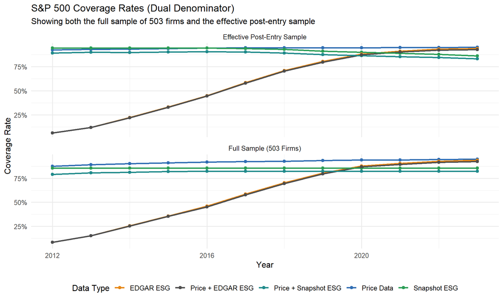

```r
yearly_coverage_plot <- coverage_by_year_dual %>%
  ggplot(aes(x = year, y = coverage_rate, color = metric_label, group = metric_label)) +
  geom_line(linewidth = 1) +
  geom_point(size = 1.8) +
  facet_wrap(~ denominator_label, ncol = 1) +
  scale_color_manual(values = metric_colors) +
  scale_y_continuous(labels = scales::percent_format(accuracy = 1)) +
  labs(
    title = "S&P 500 Coverage Rates (Dual Denominator)",
    subtitle = "Showing both the full sample of 503 firms and the effective post-entry sample",
    x = "Year",
    y = "Coverage Rate",
    color = "Data Type"
  ) +
  theme_minimal(base_size = 12) +
  theme(legend.position = "bottom")

joint_coverage_bar_plot <- coverage_by_year_dual %>%
  filter(
    denominator_type == "effective_sample",
    metric %in% c("price_and_snapshot", "price_and_edgar")
  ) %>%
  ggplot(aes(x = factor(year), y = coverage_rate, fill = metric_label)) +
  geom_col(position = "dodge", width = 0.7) +
  scale_fill_manual(values = metric_colors[c("Price + Snapshot ESG", "Price + EDGAR ESG")]) +
  scale_y_continuous(labels = scales::percent_format(accuracy = 1)) +
  labs(
    title = "Coverage of Jointly Available Samples",
    subtitle = "Effective post-entry sample definition",
    x = "Year",
    y = "Coverage Rate",
    fill = "Joint Sample Type"
  ) +
  theme_minimal(base_size = 12) +
  theme(legend.position = "bottom")

sector_heatmap_data <- coverage_by_sector_dual %>%
  filter(
    denominator_type == "effective_sample",
    coverage_period == "all_years_avg"
  ) %>%
  group_by(sector_standardized) %>%
  mutate(
    edgar_sort = coverage_rate[metric == "edgar_available"][1]
  ) %>%
  ungroup() %>%
  mutate(
    sector_standardized = reorder(sector_standardized, edgar_sort, na.rm = TRUE),
    metric_label = factor(metric_label, levels = unname(metric_labels), ordered = TRUE)
  )

sector_heatmap_plot <- sector_heatmap_data %>%
  ggplot(aes(x = metric_label, y = sector_standardized, fill = coverage_rate)) +
  geom_tile(color = "white", linewidth = 0.3) +
  geom_text(aes(label = ifelse(is.na(coverage_rate), "NA", scales::percent(coverage_rate, accuracy = 1))), size = 3) +
  scale_fill_gradient(low = "#F1F5F9", high = "#2F6DB3", labels = scales::percent_format(accuracy = 1), na.value = "#D9D9D9") +
  labs(
    title = "Sector-Level Coverage Heatmap",
    subtitle = "Effective post-entry sample definition using average coverage across the full period",
    x = "Data Type",
    y = "Standardized Sector",
    fill = "Coverage Rate"
  ) +
  theme_minimal(base_size = 12) +
  theme(axis.text.x = element_text(angle = 20, hjust = 1))

field_missingness_plot <- field_missingness %>%
  mutate(field = reorder(field, missing_rate)) %>%
  ggplot(aes(x = field, y = missing_rate, fill = field_group)) +
  geom_col(width = 0.75) +
  scale_y_continuous(labels = scales::percent_format(accuracy = 1)) +
  labs(
    title = "Main Panel Field Missingness",
    subtitle = "Missingness rates grouped by field family",
    x = "Field",
    y = "Missing Rate",
    fill = "Field Group"
  ) +
  theme_minimal(base_size = 12) +
  theme(axis.text.y = element_text(size = 9)) +
  coord_flip()

bucket_plot <- company_coverage_buckets %>%
  mutate(company_bucket = factor(company_bucket, levels = bucket_levels, ordered = TRUE)) %>%
  ggplot(aes(x = company_bucket, y = company_count, fill = company_bucket)) +
  geom_col(width = 0.7, show.legend = FALSE) +
  geom_text(aes(label = scales::percent(share, accuracy = 0.1)), vjust = -0.4, size = 3.5) +
  labs(
    title = "Firm Coverage Bucket Distribution",
    subtitle = "Main usability combinations aggregated at the firm level",
    x = "Coverage Bucket",
    y = "Number of Firms"
  ) +
  theme_minimal(base_size = 12) +
  theme(axis.text.x = element_text(angle = 18, hjust = 1))

ggplot2::ggsave(OUTPUT_USABILITY_FILES$yearly_lines, yearly_coverage_plot, width = 10, height = 7, dpi = 160)
ggplot2::ggsave(OUTPUT_USABILITY_FILES$joint_bars, joint_coverage_bar_plot, width = 10, height = 6, dpi = 160)
ggplot2::ggsave(OUTPUT_USABILITY_FILES$sector_heatmap, sector_heatmap_plot, width = 11, height = 7.5, dpi = 160)
ggplot2::ggsave(OUTPUT_USABILITY_FILES$missingness_bar, field_missingness_plot, width = 11, height = 10, dpi = 160)
ggplot2::ggsave(OUTPUT_USABILITY_FILES$bucket_bar, bucket_plot, width = 10, height = 6, dpi = 160)

yearly_coverage_plot
```

### 12.4 Audit Validation Checks

Assert invariants that must hold for the audit tables to be internally consistent: - Denominators match expected counts - Coverage rates are bounded in [0, 1] - Joint coverage never exceeds the min of its components - Snapshot coverage is constant across years (cross-sectional source) - Sector labels have been standardized - New dual-denominator definitions match legacy single-denominator figures

```r
# ---- Cross-check new coverage definitions against legacy outputs ----
legacy_compare <- coverage_by_year_dual %>%
  filter(
    denominator_type == "full_sample",
    metric %in% c("price_available", "snapshot_available", "edgar_available")
  ) %>%
  select(year, metric, coverage_rate) %>%
  pivot_wider(names_from = metric, values_from = coverage_rate) %>%
  left_join(
    legacy_coverage_by_year %>%
      select(year, price_coverage, snapshot_coverage, edgar_coverage),
    by = "year"
  )

joint_edgar_check <- coverage_by_year_dual %>%
  select(year, denominator_type, metric, coverage_rate) %>%
  pivot_wider(names_from = metric, values_from = coverage_rate) %>%
  transmute(check = price_and_edgar <= pmin(price_available, edgar_available)) %>%
  pull(check)

joint_snapshot_check <- coverage_by_year_dual %>%
  select(year, denominator_type, metric, coverage_rate) %>%
  pivot_wider(names_from = metric, values_from = coverage_rate) %>%
  transmute(check = price_and_snapshot <= pmin(price_available, snapshot_available)) %>%
  pull(check)

stopifnot(all(coverage_by_year_dual$denominator[coverage_by_year_dual$denominator_type == "full_sample"] == 503))
stopifnot(all(coverage_by_year_dual$denominator[coverage_by_year_dual$denominator_type == "effective_sample"] <= 503))
stopifnot(all(coverage_by_year_dual$coverage_rate[!is.na(coverage_by_year_dual$coverage_rate)] >= 0))
stopifnot(all(coverage_by_year_dual$coverage_rate[!is.na(coverage_by_year_dual$coverage_rate)] <= 1))
stopifnot(all(coverage_by_year_dual$coverage_rate[!is.na(coverage_by_year_dual$coverage_rate)] %>% is.finite()))
stopifnot(all(joint_edgar_check[!is.na(joint_edgar_check)]))
stopifnot(all(joint_snapshot_check[!is.na(joint_snapshot_check)]))
stopifnot(
  dplyr::n_distinct(
    coverage_by_year_dual$coverage_rate[
      coverage_by_year_dual$denominator_type == "full_sample" &
        coverage_by_year_dual$metric == "snapshot_available"
    ]
  ) == 1
)
stopifnot(!any(panel_for_usability$sector_standardized %in% c("Technology", "Healthcare", "Financial Services"), na.rm = TRUE))
stopifnot(all(round(legacy_compare$price_available, 4) == round(legacy_compare$price_coverage, 4)))
stopifnot(all(round(legacy_compare$snapshot_available, 4) == round(legacy_compare$snapshot_coverage, 4)))
stopifnot(all(round(legacy_compare$edgar_available, 4) == round(legacy_compare$edgar_coverage, 4)))

validation_summary <- tibble(
  check = c(
    "Full-sample denominator is always 503",
    "Effective-sample denominator never exceeds 503",
    "All coverage rates lie within [0, 1]",
    "Joint coverage never exceeds single-source coverage",
    "Snapshot annual coverage is constant",
    "Sector labels are standardized",
    "New and legacy yearly coverage definitions match"
  ),
  result = "PASS"
)

knitr::kable(validation_summary)
```

| check | result |
| --- | --- |
| Full-sample denominator is always 503 | PASS |
| Effective-sample denominator never exceeds 503 | PASS |
| All coverage rates lie within [0, 1] | PASS |
| Joint coverage never exceeds single-source coverage | PASS |
| Snapshot annual coverage is constant | PASS |
| Sector labels are standardized | PASS |
| New and legacy yearly coverage definitions match | PASS |

### 12.5 Usability Analysis Output Files

```r
usability_output_table <- tibble(
  file = to_project_relative(unname(unlist(OUTPUT_USABILITY_FILES))),
  description = c(
    "Dual-denominator usability overview",
    "Dual-denominator coverage by year",
    "Dual-denominator coverage by sector",
    "Field missingness summary for the main panel",
    "Coverage distribution by firm-level usability bucket",
    "Special sample and boundary-case summary",
    "Line chart of dual-denominator coverage by year",
    "Yearly bar chart for jointly available samples",
    "Sector coverage heatmap",
    "Field missingness bar chart",
    "Firm coverage bucket distribution"
  )
)

knitr::kable(usability_output_table)
```

| file | description |
| --- | --- |
| output/01_data_usability/01_overview_dual_denominator.csv | Dual-denominator usability overview |
| output/01_data_usability/02_coverage_by_year_dual_denominator.csv | Dual-denominator coverage by year |
| output/01_data_usability/03_coverage_by_sector_dual_denominator.csv | Dual-denominator coverage by sector |
| output/01_data_usability/04_field_missingness.csv | Field missingness summary for the main panel |
| output/01_data_usability/05_company_coverage_buckets.csv | Coverage distribution by firm-level usability bucket |
| output/01_data_usability/06_special_cases_summary.csv | Special sample and boundary-case summary |
| output/01_data_usability/11_yearly_coverage_lines.png | Line chart of dual-denominator coverage by year |
| output/01_data_usability/12_yearly_joint_coverage_bars.png | Yearly bar chart for jointly available samples |
| output/01_data_usability/13_sector_coverage_heatmap.png | Sector coverage heatmap |
| output/01_data_usability/14_field_missingness_bar.png | Field missingness bar chart |
| output/01_data_usability/15_company_bucket_bar.png | Firm coverage bucket distribution |

## 13 Machine Learning Helper Functions

Shared functions for crash-label construction, classification metrics, feature preprocessing, and model fitting. Used by the two-year crash-risk warning pipeline in the next section.

```r
# ---------------------------------------------------------------------------
# Python fallback for Yahoo Finance price downloads
# ---------------------------------------------------------------------------
# When cached price files are missing, we call a Python script that uses
# Yahoo Finance's chart API. R's quantmod/tidyquant can be unreliable for
# bulk downloads, hence the Python fallback.

detect_workspace_python <- function() {
  candidates <- c(
    file.path(Sys.getenv("USERPROFILE"), ".cache", "codex-runtimes", "codex-primary-runtime", "dependencies", "python", "python.exe"),
    Sys.which("python")
  )

  valid_candidates <- candidates[nzchar(candidates) & file.exists(candidates)]
  if (length(valid_candidates) == 0) {
    return(NA_character_)
  }

  valid_candidates[[1]]
}

fetch_yahoo_prices_python <- function(tickers, start_date, end_date_exclusive, output_file) {
  python_path <- detect_workspace_python()

  if (is.na(python_path) || !file.exists(python_path)) {
    stop("No accessible Python runtime was found for the Yahoo Finance fallback.")
  }

  tickers <- unique(tickers[!is.na(tickers) & nzchar(tickers)])
  tickers_file <- tempfile(fileext = ".txt")
  script_file <- tempfile(fileext = ".py")
  writeLines(tickers, tickers_file, useBytes = TRUE)

  script_lines <- c(
    "import csv",
    "import json",
    "import sys",
    "import time",
    "import urllib.parse",
    "import urllib.request",
    "from concurrent.futures import ThreadPoolExecutor, as_completed",
    "from datetime import datetime, timezone",
    "",
    "tickers_file, output_file, start_date, end_date = sys.argv[1:5]",
    "with open(tickers_file, 'r', encoding='utf-8') as handle:",
    "    tickers = [line.strip() for line in handle if line.strip()]",
    "",
    "period1 = int(datetime.fromisoformat(start_date).replace(tzinfo=timezone.utc).timestamp())",
    "period2 = int(datetime.fromisoformat(end_date).replace(tzinfo=timezone.utc).timestamp())",
    "headers = {'User-Agent': 'Mozilla/5.0'}",
    "",
    "def fetch_one(ticker):",
    "    encoded_ticker = urllib.parse.quote(ticker)",
    "    url = f'https://query2.finance.yahoo.com/v8/finance/chart/{encoded_ticker}?period1={period1}&period2={period2}&interval=1d&events=div%2Csplits&includeAdjustedClose=true'",
    "    last_error = None",
    "    for attempt in range(3):",
    "        try:",
    "            request = urllib.request.Request(url, headers=headers)",
    "            with urllib.request.urlopen(request, timeout=30) as response:",
    "                payload = json.loads(response.read().decode('utf-8'))",
    "            result = (payload.get('chart', {}) or {}).get('result')",
    "            if not result:",
    "                return ticker, [], str((payload.get('chart', {}) or {}).get('error'))",
    "            result = result[0]",
    "            timestamps = result.get('timestamp') or []",
    "            indicators = result.get('indicators') or {}",
    "            quote = (indicators.get('quote') or [{}])[0]",
    "            adj_block = (indicators.get('adjclose') or [{}])[0]",
    "            adj_values = adj_block.get('adjclose')",
    "            if adj_values is None:",
    "                adj_values = quote.get('close') or []",
    "            volume_values = quote.get('volume') or []",
    "            rows = []",
    "            for idx, one_timestamp in enumerate(timestamps):",
    "                adj_value = adj_values[idx] if idx < len(adj_values) else None",
    "                volume_value = volume_values[idx] if idx < len(volume_values) else None",
    "                if adj_value is None:",
    "                    continue",
    "                date_value = datetime.utcfromtimestamp(one_timestamp).strftime('%Y-%m-%d')",
    "                rows.append([ticker, date_value, adj_value, '' if volume_value is None else volume_value])",
    "            return ticker, rows, None",
    "        except Exception as error:",
    "            last_error = str(error)",
    "            time.sleep(0.8 * (attempt + 1))",
    "    return ticker, [], last_error",
    "",
    "all_rows = []",
    "failures = []",
    "with ThreadPoolExecutor(max_workers=8) as executor:",
    "    futures = {executor.submit(fetch_one, ticker): ticker for ticker in tickers}",
    "    for future in as_completed(futures):",
    "        ticker, rows, error_message = future.result()",
    "        if rows:",
    "            all_rows.extend(rows)",
    "        else:",
    "            failures.append((ticker, error_message))",
    "",
    "with open(output_file, 'w', newline='', encoding='utf-8') as handle:",
    "    writer = csv.writer(handle)",
    "    writer.writerow(['price_symbol', 'date', 'adj_close', 'volume'])",
    "    writer.writerows(all_rows)",
    "",
    "if failures:",
    "    sys.stderr.write('Failed tickers: ' + str(len(failures)) + '\\n')",
    "    preview = '; '.join([f'{ticker}={message}' for ticker, message in failures[:10]])",
    "    sys.stderr.write(preview + '\\n')",
    "",
    "sys.stdout.write(str(len(all_rows)))"
  )

  writeLines(script_lines, script_file, useBytes = TRUE)

  command_output <- system2(
    command = python_path,
    args = c(script_file, tickers_file, output_file, start_date, end_date_exclusive),
    stdout = TRUE,
    stderr = TRUE
  )

  if (!file.exists(output_file)) {
    stop("The Python Yahoo download fallback did not create the expected price file.")
  }

  command_output
}

# ---------------------------------------------------------------------------
# Crash-risk label construction (following Chen, Hong & Stein 2001 / JFE)
# ---------------------------------------------------------------------------
# Crash metrics are computed from weekly residual returns after removing
# market-wide movements. The key steps:
#   1. Aggregate daily log returns to weekly
#   2. Regress firm weekly returns on lead/lag market returns (Dimson 1979)
#   3. Compute NCSKEW (negative conditional skewness) and CRASH_DUMMY from residuals
# A "crash" week is any residual return below mean - 3.09 * sd (~0.1% tail).
```

```r
compute_symbol_year_crash_metrics <- function(firm_data) {
  n_obs <- nrow(firm_data)
  if (n_obs < 26) {
    return(NULL)
  }

  firm_sorted <- firm_data %>%
    arrange(week_id) %>%
    mutate(
      mkt_lag2 = lag(ret_market, 2),
      mkt_lag1 = lag(ret_market, 1),
      mkt_lead1 = lead(ret_market, 1),
      mkt_lead2 = lead(ret_market, 2)
    )

  reg_data <- firm_sorted %>%
    filter(
      !is.na(mkt_lag2), !is.na(mkt_lag1),
      !is.na(ret_market), !is.na(mkt_lead1), !is.na(mkt_lead2)
    )

  if (nrow(reg_data) < 20) {
    return(NULL)
  }

  # Regress firm weekly returns on lead/lag market returns to isolate firm-specific residual moves.
  fit <- tryCatch(
    lm(ret_week ~ mkt_lag2 + mkt_lag1 + ret_market + mkt_lead1 + mkt_lead2, data = reg_data),
    error = function(error) NULL
  )

  if (is.null(fit)) {
    return(NULL)
  }

  residual_returns <- residuals(fit)
  transformed_returns <- log(1 + residual_returns)
  transformed_returns <- transformed_returns[is.finite(transformed_returns)]

  n <- length(transformed_returns)
  if (n < 20) {
    return(NULL)
  }

  sum_w3 <- sum(transformed_returns^3)
  sum_w2 <- sum(transformed_returns^2)

  ncskew <- NA_real_
  if (sum_w2 > 0) {
    ncskew <- -(n * (n - 1)^(1.5) * sum_w3) / ((n - 1) * (n - 2) * sum_w2^(1.5))
  }

  w_mean <- mean(transformed_returns, na.rm = TRUE)
  w_sd <- sd(transformed_returns, na.rm = TRUE)
  # A crash year is flagged when at least one residual return breaches the 3.09-standard-deviation cutoff.
  crash_dummy <- as.integer(any(transformed_returns < w_mean - 3.09 * w_sd, na.rm = TRUE))

  tibble(
    NCSKEW = ncskew,
    CRASH_DUMMY = crash_dummy,
    SIGMA = w_sd,
    RET_MEAN = w_mean
  )
}

build_sp500_crash_metrics <- function(price_data) {
  # Build weekly firm and market returns because the crash-risk labels are defined on weekly residuals.
  daily_returns <- price_data %>%
    arrange(symbol, date) %>%
    group_by(symbol) %>%
    mutate(ret_daily = log(adj_close / lag(adj_close))) %>%
    ungroup() %>%
    filter(!is.na(ret_daily), is.finite(ret_daily))

  market_daily <- daily_returns %>%
    group_by(date) %>%
    summarise(
      ret_market = mean(ret_daily, na.rm = TRUE),
      .groups = "drop"
    )

  daily_with_week <- daily_returns %>%
    left_join(market_daily, by = "date") %>%
    mutate(
      year = lubridate::year(date),
      week_id = paste0(year, "_W", sprintf("%02d", lubridate::isoweek(date)))
    )

  weekly_returns <- daily_with_week %>%
    group_by(symbol, year, week_id) %>%
    summarise(
      ret_week = sum(ret_daily, na.rm = TRUE),
      ret_market = sum(ret_market, na.rm = TRUE),
      avg_volume = mean(volume, na.rm = TRUE),
      n_days = n(),
      .groups = "drop"
    ) %>%
    filter(n_days >= 3)

  symbol_year_groups <- weekly_returns %>%
    group_by(symbol, year) %>%
    group_split()

  crash_rows <- lapply(symbol_year_groups, function(group_data) {
    metric_row <- compute_symbol_year_crash_metrics(group_data)
    if (is.null(metric_row)) {
      return(NULL)
    }

    bind_cols(
      tibble(symbol = group_data$symbol[[1]], year = group_data$year[[1]]),
      metric_row
    )
  })

  crash_metrics_df <- bind_rows(Filter(Negate(is.null), crash_rows))

  monthly_volume <- daily_returns %>%
    mutate(
      year = lubridate::year(date),
      month = lubridate::month(date)
    ) %>%
    group_by(symbol, year, month) %>%
    summarise(
      monthly_volume = sum(volume, na.rm = TRUE),
      .groups = "drop"
    )

  annual_volume <- monthly_volume %>%
    group_by(symbol, year) %>%
    summarise(
      avg_monthly_volume = mean(monthly_volume, na.rm = TRUE),
      .groups = "drop"
    )

  # DTURN captures the year-over-year change in average monthly trading volume.
  dturn_df <- annual_volume %>%
    arrange(symbol, year) %>%
    group_by(symbol) %>%
    mutate(DTURN = avg_monthly_volume - lag(avg_monthly_volume)) %>%
    ungroup() %>%
    select(symbol, year, DTURN)

  crash_metrics_df %>%
    left_join(dturn_df, by = c("symbol", "year")) %>%
    arrange(symbol, year)
}

# ---------------------------------------------------------------------------
# Classification metrics (all handle NA values via valid_index filtering)
# ---------------------------------------------------------------------------
# ROC AUC computed via the Wilcoxon-Mann-Whitney rank-sum formula

calc_roc_auc <- function(truth, probability) {
  truth <- as.integer(truth)
  valid_index <- !is.na(truth) & !is.na(probability)
  truth <- truth[valid_index]
  probability <- probability[valid_index]

  positive_total <- sum(truth == 1)
  negative_total <- sum(truth == 0)

  if (positive_total == 0 || negative_total == 0) {
    return(NA_real_)
  }

  ranks <- rank(probability, ties.method = "average")
  positive_rank_sum <- sum(ranks[truth == 1])

  (positive_rank_sum - positive_total * (positive_total + 1) / 2) / (positive_total * negative_total)
}

# PR AUC via the trapezoidal rule on sorted predictions
calc_pr_auc <- function(truth, probability) {
  truth <- as.integer(truth)
  valid_index <- !is.na(truth) & !is.na(probability)
  truth <- truth[valid_index]
  probability <- probability[valid_index]

  positive_total <- sum(truth == 1)
  if (positive_total == 0) {
    return(NA_real_)
  }

  order_index <- order(probability, decreasing = TRUE)
  sorted_truth <- truth[order_index]
  true_positive <- cumsum(sorted_truth == 1)
  false_positive <- cumsum(sorted_truth == 0)
  precision <- true_positive / (true_positive + false_positive)
  recall <- true_positive / positive_total
  precision <- c(1, precision)
  recall <- c(0, recall)

  sum((recall[-1] - recall[-length(recall)]) * precision[-1], na.rm = TRUE)
}

# F-beta score with beta = 0.5 (weights precision 2× more than recall).
# We prioritize precision because flagging too many non-crash firms as "high risk"
# erodes the credibility of the warning system more than missing a few crashes.
calc_fbeta <- function(precision, recall, beta_weight = 0.5) {
  if (is.na(precision) || is.na(recall) || (precision + recall) == 0) {
    return(NA_real_)
  }
```

```r
  beta_square <- beta_weight ^ 2
  (1 + beta_square) * precision * recall / (beta_square * precision + recall)
}

calc_precision_at_top_share <- function(truth, probability, share = 0.10) {
  truth <- as.integer(truth)
  valid_index <- !is.na(truth) & !is.na(probability)
  truth <- truth[valid_index]
  probability <- probability[valid_index]

  if (length(truth) == 0) {
    return(NA_real_)
  }

  k <- max(1, ceiling(length(truth) * share))
  order_index <- order(probability, decreasing = TRUE)
  mean(truth[order_index[seq_len(k)]] == 1)
}

calc_top_n_hit_summary <- function(truth, probability, top_n = 20) {
  truth <- as.integer(truth)
  valid_index <- !is.na(truth) & !is.na(probability)
  truth <- truth[valid_index]
  probability <- probability[valid_index]

  if (length(truth) == 0) {
    return(list(rate = NA_real_, hits = NA_integer_, k = 0L))
  }

  k <- min(top_n, length(truth))
  order_index <- order(probability, decreasing = TRUE)
  hits <- sum(truth[order_index[seq_len(k)]] == 1)

  list(
    rate = hits / k,
    hits = hits,
    k = k
  )
}

build_pr_curve_data <- function(actual, probability, model_label) {
  valid_index <- !is.na(actual) & !is.na(probability)
  actual <- as.integer(actual[valid_index])
  probability <- as.numeric(probability[valid_index])

  if (length(actual) == 0 || sum(actual == 1) == 0) {
    return(tibble())
  }

  order_index <- order(probability, decreasing = TRUE)
  sorted_truth <- actual[order_index]
  sorted_probability <- probability[order_index]
  true_positive <- cumsum(sorted_truth == 1)
  false_positive <- cumsum(sorted_truth == 0)
  positive_total <- sum(sorted_truth == 1)

  tibble(
    model_label = model_label,
    step = seq_along(sorted_probability),
    threshold = sorted_probability,
    precision = true_positive / (true_positive + false_positive),
    recall = true_positive / positive_total
  )
}

choose_threshold_from_validation <- function(threshold_table) {
  threshold_table %>%
    mutate(
      rank_f0_5 = dplyr::dense_rank(desc(mean_f0_5)),
      rank_precision = dplyr::dense_rank(desc(mean_precision))
    ) %>%
    arrange(rank_f0_5, rank_precision, desc(mean_pr_auc_proxy), threshold) %>%
    slice(1) %>%
    select(-rank_f0_5, -rank_precision)
}

# ---- Feature preprocessing ----
# Prepares feature matrices for model fitting:
#   - Continuous features: median-impute NAs, optionally standardize (z-score)
#   - Binary features (missingness flags, availability dummies): impute NAs to 0
# Median imputation is used (rather than mean) because it's robust to outliers in
# financial variables like volume and drawdown.

build_model_frame <- function(train_data, apply_data, feature_cols, binary_features = character(), standardize = FALSE) {
  train_frame <- train_data %>%
    select(all_of(feature_cols)) %>%
    mutate(across(everything(), as.numeric))

  apply_frame <- apply_data %>%
    select(all_of(feature_cols)) %>%
    mutate(across(everything(), as.numeric))

  binary_features <- intersect(binary_features, feature_cols)
  continuous_features <- setdiff(feature_cols, binary_features)

  if (length(binary_features) > 0) {
    for (feature_name in binary_features) {
      train_frame[[feature_name]][is.na(train_frame[[feature_name]])] <- 0
      apply_frame[[feature_name]][is.na(apply_frame[[feature_name]])] <- 0
    }
  }

  if (length(continuous_features) > 0) {
    for (feature_name in continuous_features) {
      median_value <- median(train_frame[[feature_name]], na.rm = TRUE)
      if (!is.finite(median_value)) {
        median_value <- 0
      }

      train_frame[[feature_name]][is.na(train_frame[[feature_name]])] <- median_value
      apply_frame[[feature_name]][is.na(apply_frame[[feature_name]])] <- median_value

      if (standardize) {
        mean_value <- mean(train_frame[[feature_name]], na.rm = TRUE)
        sd_value <- sd(train_frame[[feature_name]], na.rm = TRUE)
        if (!is.finite(sd_value) || sd_value == 0) {
          sd_value <- 1
        }

        train_frame[[feature_name]] <- (train_frame[[feature_name]] - mean_value) / sd_value
        apply_frame[[feature_name]] <- (apply_frame[[feature_name]] - mean_value) / sd_value
      }
    }
  }

  list(
    train = train_frame,
    apply = apply_frame
  )
}
```

## 14 Machine Learning Risk Warning — Two-Year External Validation

The two-year warning extends the one-year setup with a longer forecast window: a firm is flagged if it crashes in **either** of the next two years. This reduces false negatives at the cost of more false positives, which may be acceptable for screening systems that prioritize recall over precision.

The pipeline mirrors the one-year structure but with: - Two-year labels: `future_2y_crash_dummy = crash_t1 | crash_t2` - Two-year price extensions (2024 + 2025 fetched) - Feature-year CV instead of target-year CV - Confusion matrix outputs for all models

### 14.1 Two-Year Machine Learning Helper Functions

```r
# ---- Standardize raw Yahoo Finance CSV into the canonical price format ----
standardize_warning_price_frame <- function(price_raw, price_map) {
  price_raw <- price_raw %>%
    mutate(
      price_symbol = as.character(price_symbol),
      date = as.Date(date),
      adj_close = as.numeric(adj_close),
      volume = as.numeric(volume)
    ) %>%
    filter(!is.na(adj_close))

  price_has_metadata <- all(
    c("symbol", "company_name", "cik", "gics_sector", "gics_sub_industry") %in% names(price_raw)
  )

  if (price_has_metadata) {
    price_raw %>%
      transmute(
        price_symbol = price_symbol,
        date = date,
        adj_close = adj_close,
        volume = volume,
        symbol = as.character(symbol),
        company_name = as.character(company_name),
        cik = cik,
        gics_sector = as.character(gics_sector),
        gics_sub_industry = as.character(gics_sub_industry)
      ) %>%
      arrange(symbol, date)
  } else {
    price_raw %>%
      select(price_symbol, date, adj_close, volume) %>%
      inner_join(price_map, by = c("price_symbol" = "symbol")) %>%
      transmute(
        price_symbol = price_symbol,
        date = date,
        adj_close = adj_close,
        volume = volume,
        symbol = price_symbol,
        company_name = as.character(company_name),
        cik = cik,
        gics_sector = as.character(gics_sector),
        gics_sub_industry = as.character(gics_sub_industry)
      ) %>%
      arrange(symbol, date)
  }
}

# ---- Fetch or load a single year of daily prices, caching to CSV ----
ensure_warning_price_year <- function(year_value, output_file, price_map, force_refresh = FALSE) {
  start_date <- sprintf("%d-01-01", year_value)
  end_date_exclusive <- sprintf("%d-01-01", year_value + 1L)

  if (!file.exists(output_file) || force_refresh) {
    message(sprintf(">>> Fetching %d daily prices through the Python Yahoo Finance fallback", year_value))
    fetch_log <- fetch_yahoo_prices_python(
      tickers = price_map$symbol,
      start_date = start_date,
      end_date_exclusive = end_date_exclusive,
      output_file = output_file
    )
    message(paste(fetch_log, collapse = "\n"))
  }

  standardized_prices <- readr::read_csv(output_file, show_col_types = FALSE) %>%
    standardize_warning_price_frame(price_map = price_map)

  data.table::fwrite(standardized_prices, output_file)
  standardized_prices
}

calc_classification_metrics <- function(actual, probability, threshold = 0.5) {
  valid_index <- !is.na(actual) & !is.na(probability)
  actual <- as.integer(actual[valid_index])
  probability <- as.numeric(probability[valid_index])

  if (length(actual) == 0) {
    return(tibble())
  }

  predicted_class <- ifelse(probability >= threshold, 1L, 0L)
  true_positive <- sum(predicted_class == 1 & actual == 1)
  true_negative <- sum(predicted_class == 0 & actual == 0)
  false_positive <- sum(predicted_class == 1 & actual == 0)
  false_negative <- sum(predicted_class == 0 & actual == 1)

  precision <- if ((true_positive + false_positive) == 0) NA_real_ else true_positive / (true_positive + false_positive)
  recall <- if ((true_positive + false_negative) == 0) NA_real_ else true_positive / (true_positive + false_negative)
  specificity <- if ((true_negative + false_positive) == 0) NA_real_ else true_negative / (true_negative + false_positive)
  balanced_accuracy <- if (all(is.na(c(recall, specificity)))) {
    NA_real_
  } else {
    mean(c(recall, specificity), na.rm = TRUE)
  }
  top20_summary <- calc_top_n_hit_summary(actual, probability, top_n = 20)

  tibble(
    selected_threshold = threshold,
    n_eval = length(actual),
    positive_count = sum(actual == 1),
    positive_rate = mean(actual == 1),
    predicted_positive_count = sum(predicted_class == 1),
    accuracy = (true_positive + true_negative) / length(actual),
    balanced_accuracy = balanced_accuracy,
    precision = precision,
    recall = recall,
    specificity = specificity,
    f0_5 = calc_fbeta(precision, recall, beta_weight = 0.5),
    roc_auc = calc_roc_auc(actual, probability),
    pr_auc = calc_pr_auc(actual, probability),
    precision_at_top10 = calc_precision_at_top_share(actual, probability, share = 0.10),
    top20_hit_rate = top20_summary$rate,
    hits_in_top20 = top20_summary$hits,
    top20_evaluated_n = top20_summary$k,
    true_positive = true_positive,
    true_negative = true_negative,
    false_positive = false_positive,
    false_negative = false_negative
  )
}

build_threshold_metrics <- function(actual, probability, thresholds) {
  bind_rows(lapply(thresholds, function(one_threshold) {
    calc_classification_metrics(actual, probability, threshold = one_threshold) %>%
      mutate(threshold = one_threshold)
  }))
}
# ---- Build a labeled confusion matrix for model comparison ----
build_confusion_matrix_table <- function(actual, probability, threshold = 0.5) {
  valid_index <- !is.na(actual) & !is.na(probability)
  actual <- as.integer(actual[valid_index])
  probability <- as.numeric(probability[valid_index])

  if (length(actual) == 0) {
    return(tibble())
  }

  predicted_class <- ifelse(probability >= threshold, 1L, 0L)
  true_positive <- sum(predicted_class == 1 & actual == 1)
  true_negative <- sum(predicted_class == 0 & actual == 0)
  false_positive <- sum(predicted_class == 1 & actual == 0)
  false_negative <- sum(predicted_class == 0 & actual == 1)

  tibble(
    selected_threshold = threshold,
    actual_class = c("Actual Crash", "Actual No Crash", "Actual No Crash", "Actual Crash"),
    predicted_class = c("Predicted Crash", "Predicted No Crash", "Predicted Crash", "Predicted No Crash"),
    cell = c("TP", "TN", "FP", "FN"),
    count = c(true_positive, true_negative, false_positive, false_negative)
  ) %>%
    mutate(
      n_eval = sum(count),
      share = ifelse(n_eval > 0, count / n_eval, NA_real_)
    )
}

fit_weighted_logistic_model_target <- function(train_data, apply_data, feature_cols, target_col, binary_features = character()) {
  prepared_frames <- build_model_frame(
    train_data = train_data,
    apply_data = apply_data,
    feature_cols = feature_cols,
    binary_features = binary_features,
    standardize = TRUE
  )

  target_vector <- as.integer(train_data[[target_col]])
  positive_count <- sum(target_vector == 1, na.rm = TRUE)
  negative_count <- sum(target_vector == 0, na.rm = TRUE)

  if (positive_count == 0 || negative_count == 0) {
    return(NULL)
  }

  case_weights <- ifelse(target_vector == 1, negative_count / positive_count, 1)
  fit_data <- bind_cols(tibble(target = target_vector), prepared_frames$train)

  glm_fit <- tryCatch(
    glm(target ~ ., data = fit_data, family = binomial(), weights = case_weights),
    error = function(error) NULL
  )

  if (is.null(glm_fit)) {
    return(NULL)
  }

  predicted_probability <- as.numeric(predict(glm_fit, newdata = prepared_frames$apply, type = "response"))
  predicted_probability <- pmin(pmax(predicted_probability, 1e-6), 1 - 1e-6)

  coefficient_table <- summary(glm_fit)$coefficients

  list(
    probability = predicted_probability,
    fitted_model = glm_fit,
    coefficient_table = tibble(
      term = rownames(coefficient_table),
      estimate = as.numeric(coefficient_table[, 1]),
      std_error = as.numeric(coefficient_table[, 2]),
      statistic = as.numeric(coefficient_table[, 3]),
      p_value = as.numeric(coefficient_table[, 4])
    )
  )
}

fit_ranger_probability_model_target <- function(train_data, apply_data, feature_cols, target_col, binary_features = character()) {
  prepared_frames <- build_model_frame(
    train_data = train_data,
    apply_data = apply_data,
    feature_cols = feature_cols,
    binary_features = binary_features,
    standardize = FALSE
  )

  target_vector <- as.integer(train_data[[target_col]])
  positive_count <- sum(target_vector == 1, na.rm = TRUE)
  negative_count <- sum(target_vector == 0, na.rm = TRUE)

  if (positive_count == 0 || negative_count == 0) {
    return(NULL)
  }

  case_weights <- ifelse(target_vector == 1, negative_count / positive_count, 1)
  fit_data <- bind_cols(
    tibble(target = factor(target_vector, levels = c(0, 1))),
    prepared_frames$train
  )

  ranger_fit <- tryCatch(
    ranger::ranger(
      target ~ .,
      data = fit_data,
      probability = TRUE,
      num.trees = 800,
      importance = "impurity",
      case.weights = case_weights,
      seed = 20260425,
      mtry = max(1, floor(sqrt(length(feature_cols))))
    ),
    error = function(error) NULL
  )

  if (is.null(ranger_fit)) {
    return(NULL)
  }
   prediction_matrix <- predict(ranger_fit, data = prepared_frames$apply)$predictions
  probability_column <- if ("1" %in% colnames(prediction_matrix)) prediction_matrix[, "1"] else prediction_matrix[, ncol(prediction_matrix)]

  list(
    probability = as.numeric(probability_column),
    fitted_model = ranger_fit,
    importance_table = tibble(
      term = names(ranger_fit$variable.importance),
      importance = as.numeric(ranger_fit$variable.importance)
    ) %>%
      arrange(desc(importance))
  )
}
```

### 14.2 Build 2024-2025 Prices and Two-Year Labels

```r
price_map_ml <- final_panel %>%
  distinct(symbol, company_name, cik, gics_sector, gics_sub_industry)

price_2024 <- ensure_warning_price_year(
  year_value = WARNING_EXTERNAL_START_YEAR,
  output_file = DERIVED_ML_FILES$price_2024,
  price_map = price_map_ml,
  force_refresh = FORCE_REFRESH_WARNING_PRICES
)
```

```
## >>> Fetching 2024 daily prices through the Python Yahoo Finance fallback
```

```r
price_2025 <- ensure_warning_price_year(
  year_value = WARNING_EXTERNAL_END_YEAR,
  output_file = DERIVED_ML_FILES$price_2025,
  price_map = price_map_ml,
  force_refresh = FORCE_REFRESH_WARNING_PRICES
)
```

```
## >>> Fetching 2025 daily prices through the Python Yahoo Finance fallback
```

```r
price_daily_extended <- bind_rows(
  price_daily %>%
    select(price_symbol, date, adj_close, volume, symbol, company_name, cik, gics_sector, gics_sub_industry),
  price_2024,
  price_2025
) %>%
  distinct(symbol, date, .keep_all = TRUE) %>%
  arrange(symbol, date)

data.table::fwrite(price_daily_extended, DERIVED_ML_FILES$price_daily_extended)

if (!file.exists(DERIVED_ML_FILES$crash_metrics_extended) || FORCE_REBUILD_WARNING_LABELS) {
  message(">>> Rebuilding crash metrics through 2025")
  crash_metrics_extended <- build_sp500_crash_metrics(price_daily_extended)
  data.table::fwrite(crash_metrics_extended, DERIVED_ML_FILES$crash_metrics_extended)
} else {
  crash_metrics_extended <- readr::read_csv(
    DERIVED_ML_FILES$crash_metrics_extended,
    show_col_types = FALSE
  )
}
```

```
## >>> Rebuilding crash metrics through 2025
```

```r
crash_metrics_extended <- crash_metrics_extended %>%
  mutate(
    year = as.integer(year),
    NCSKEW = as.numeric(NCSKEW),
    CRASH_DUMMY = as.integer(CRASH_DUMMY),
    SIGMA = as.numeric(SIGMA),
    RET_MEAN = as.numeric(RET_MEAN),
    DTURN = as.numeric(DTURN)
  ) %>%
  arrange(symbol, year)

two_year_label_summary <- crash_metrics_extended %>%
  filter(year >= 2013, year <= WARNING_EXTERNAL_END_YEAR) %>%
  group_by(year) %>%
  summarise(
    firms_with_label = n(),
    crash_rate = mean(CRASH_DUMMY, na.rm = TRUE),
    mean_ncskew = mean(NCSKEW, na.rm = TRUE),
    .groups = "drop"
  )

two_year_label_summary %>% knitr::kable(digits = 4)
```

| year | firms_with_label | crash_rate | mean_ncskew |
| --- | --- | --- | --- |
| 2013 | 446 | 0.2332 | 0.1505 |
| 2014 | 450 | 0.2311 | 0.1711 |
| 2015 | 457 | 0.2144 | 0.1635 |
| 2016 | 459 | 0.2854 | 0.2144 |
| 2017 | 464 | 0.2737 | 0.2579 |
| 2018 | 465 | 0.2538 | 0.2852 |
| 2019 | 470 | 0.3191 | 0.4459 |
| 2020 | 472 | 0.1610 | 0.2062 |
| 2021 | 473 | 0.1734 | 0.1528 |
| 2022 | 474 | 0.2890 | 0.4894 |
| 2023 | 476 | 0.2395 | 0.2787 |
| 2024 | 488 | 0.2459 | 0.2168 |
| 2025 | 488 | 0.3012 | 0.4295 |

### 14.3 Build the Two-Year Supervised Learning Sample

The two-year sample pairs feature year (t) with a two-year-ahead window [t+1, t+2]. A firm is labeled positive if it experiences a crash in either year. The label construction: - `crash_t1`: crash event in t+1 - `crash_t2`: crash event in t+2 - `future_2y_crash_dummy`: crash_t1 | crash_t2 (only when both years are observed)

```r
# ---- Reuse the same feature column groups from the one-year setup ----
price_feature_cols <- c(
  "annual_return",
  "annual_log_return",
  "annual_volatility",
  "max_drawdown",
  "avg_volume",
  "median_volume",
  "n_trading_days"
)

snapshot_numeric_cols <- c(
  "snapshot_total_esg_risk",
  "snapshot_environment_risk",
  "snapshot_social_risk",
  "snapshot_governance_risk",
  "snapshot_controversy_score",
  "snapshot_esg_percentile"
)

edgar_numeric_cols <- c(
  "edgar_e_score",
  "edgar_s_score",
  "edgar_g_score",
  "edgar_esg_total",
  "edgar_word_count"
)

warning_feature_panel_2y <- panel_for_usability %>%
  transmute(
    symbol,
    company_name,
    sector_standardized,
    feature_year = year,
    window_start_year = year + 1L,
    window_end_year = year + 2L,
    eligible_by_year,
    across(all_of(price_feature_cols)),
    snapshot_available = as.integer(snapshot_available),
    edgar_available = as.integer(edgar_available),
    across(all_of(snapshot_numeric_cols)),
    across(all_of(edgar_numeric_cols))
  )

crash_label_t1 <- crash_metrics_extended %>%
  transmute(
    symbol,
    window_start_year = year,
    crash_t1 = as.integer(CRASH_DUMMY),
    ncskew_t1 = as.numeric(NCSKEW)
  )

crash_label_t2 <- crash_metrics_extended %>%
  transmute(
    symbol,
    window_end_year = year,
    crash_t2 = as.integer(CRASH_DUMMY),
    ncskew_t2 = as.numeric(NCSKEW)
  )

# ---- Merge t+1 and t+2 crash labels into a single two-year outcome ----
ml_warning_panel_2y <- warning_feature_panel_2y %>%
  left_join(crash_label_t1, by = c("symbol", "window_start_year")) %>%
  left_join(crash_label_t2, by = c("symbol", "window_end_year")) %>%
  mutate(
    across(all_of(snapshot_numeric_cols), ~ suppressWarnings(readr::parse_number(as.character(.x)))),
    across(all_of(edgar_numeric_cols), ~ suppressWarnings(readr::parse_number(as.character(.x)))),
    across(all_of(price_feature_cols), ~ suppressWarnings(readr::parse_number(as.character(.x)))),
    ncskew_t1 = suppressWarnings(readr::parse_number(as.character(ncskew_t1))),
    ncskew_t2 = suppressWarnings(readr::parse_number(as.character(ncskew_t2))),
    crash_t1 = as.integer(crash_t1),
    crash_t2 = as.integer(crash_t2)
  )

for (feature_name in snapshot_numeric_cols) {
  ml_warning_panel_2y[[paste0(feature_name, "_is_missing")]] <- as.integer(is.na(ml_warning_panel_2y[[feature_name]]))
}

for (feature_name in edgar_numeric_cols) {
  ml_warning_panel_2y[[paste0(feature_name, "_is_missing")]] <- as.integer(is.na(ml_warning_panel_2y[[feature_name]]))
}

ml_warning_panel_2y <- ml_warning_panel_2y %>%
  mutate(
    window_complete = !is.na(crash_t1) & !is.na(crash_t2),
    future_2y_crash_dummy = if_else(
      window_complete,
      as.integer(crash_t1 == 1L | crash_t2 == 1L),
      NA_integer_
    ),
    data_split = case_when(
      feature_year >= START_YEAR & feature_year <= (END_YEAR - 1L) ~ "pre_external_training_pool",
      feature_year == END_YEAR ~ "external_2024_2025_test",
      TRUE ~ "unused"
    )
  ) %>%
  filter(feature_year >= START_YEAR, window_end_year <= WARNING_EXTERNAL_END_YEAR)

training_pool <- ml_warning_panel_2y %>%
  filter(
    eligible_by_year,
    window_complete,
    data_split == "pre_external_training_pool"
  )

external_test_pool <- ml_warning_panel_2y %>%
  filter(
    eligible_by_year,
    window_complete,
    feature_year == END_YEAR,
    data_split == "external_2024_2025_test"
  )

data.table::fwrite(ml_warning_panel_2y, DERIVED_ML_FILES$ml_panel)
data.table::fwrite(training_pool, OUTPUT_ML_FILES$training_panel)

tibble(
  sample_name = c("training_pool_2y", "external_test_pool_2y"),
  rows = c(nrow(training_pool), nrow(external_test_pool)),
  companies = c(dplyr::n_distinct(training_pool$symbol), dplyr::n_distinct(external_test_pool$symbol)),
  positive_rate = c(mean(training_pool$future_2y_crash_dummy, na.rm = TRUE), mean(external_test_pool$future_2y_crash_dummy, na.rm = TRUE)),
  feature_year_span = c(
    paste(range(training_pool$feature_year, na.rm = TRUE), collapse = "-"),
    paste(range(external_test_pool$feature_year, na.rm = TRUE), collapse = "-")
  ),
  window_span = c(
    paste0(min(training_pool$window_start_year, na.rm = TRUE), "-", max(training_pool$window_end_year, na.rm = TRUE)),
    paste0(min(external_test_pool$window_start_year, na.rm = TRUE), "-", max(external_test_pool$window_end_year, na.rm = TRUE))
  )
) %>%
  knitr::kable(digits = 4)
```

| sample_name | rows | companies | positive_rate | feature_year_span | window_span |
| --- | --- | --- | --- | --- | --- |
| training_pool_2y | 4235 | 459 | 0.4158 | 2012-2022 | 2013-2024 |
| external_test_pool_2y | 483 | 483 | 0.4741 | 2023-2023 | 2024-2025 |

### 14.4 Two-Year Model Training and Threshold Selection

Training uses **feature-year CV** (2018-2022): models train on earlier feature years and validate on each holdout feature year. This differs from the one-year setup (target-year CV) because each feature year’s validation window spans two future years, making target-year splits less clean.

The same 6 model specifications (3 feature sets × 2 algorithms) are reused so one-year and two-year results are directly comparable.

```r
snapshot_missing_flags <- paste0(snapshot_numeric_cols, "_is_missing")
edgar_missing_flags <- paste0(edgar_numeric_cols, "_is_missing")

# ---- Mirror the one-year specifications (same feature sets, same algorithms) ----
model_specifications <- tibble(
  feature_set_id = c("price_baseline", "price_plus_snapshot_esg", "price_plus_full_esg"),
  feature_set_label = c("Price Baseline", "Price + Snapshot ESG", "Price + Full ESG"),
  feature_columns = list(
    price_feature_cols,
    c(price_feature_cols, "snapshot_available", snapshot_numeric_cols, snapshot_missing_flags),
    c(price_feature_cols, "snapshot_available", snapshot_numeric_cols, snapshot_missing_flags, "edgar_available", edgar_numeric_cols, edgar_missing_flags)
  ),
  binary_columns = list(
    character(),
    c("snapshot_available", snapshot_missing_flags),
    c("snapshot_available", snapshot_missing_flags, "edgar_available", edgar_missing_flags)
  )
) %>%
  tidyr::crossing(
    tibble(
      model_type = c("weighted_logistic", "ranger_probability_forest"),
      model_label = c("Weighted Logistic", "Probability Random Forest")
    )
  ) %>%
  mutate(
    model_key = paste(feature_set_id, model_type, sep = "__"),
    model_display = paste(feature_set_label, model_label, sep = " | ")
  )

# ---- Feature-year CV: validate on 2018-2022 features, reserve 2023 for external test ----
validation_feature_years <- 2018:2022
threshold_grid <- seq(0.05, 0.95, by = 0.01)

validation_fold_results <- list()
validation_threshold_results <- list()

for (spec_index in seq_len(nrow(model_specifications))) {
  one_spec <- model_specifications[spec_index, ]
  feature_columns <- one_spec$feature_columns[[1]]
  binary_columns <- one_spec$binary_columns[[1]]

  for (one_validation_feature_year in validation_feature_years) {
    train_fold <- training_pool %>%
      filter(feature_year < one_validation_feature_year)

    valid_fold <- training_pool %>%
      filter(feature_year == one_validation_feature_year)

    if (nrow(train_fold) == 0 || nrow(valid_fold) == 0) {
      next
    }

    fitted_output <- if (one_spec$model_type[[1]] == "weighted_logistic") {
      fit_weighted_logistic_model_target(
        train_data = train_fold,
        apply_data = valid_fold,
        feature_cols = feature_columns,
        target_col = "future_2y_crash_dummy",
        binary_features = binary_columns
      )
    } else {
      fit_ranger_probability_model_target(
        train_data = train_fold,
        apply_data = valid_fold,
        feature_cols = feature_columns,
        target_col = "future_2y_crash_dummy",
        binary_features = binary_columns
      )
    }

    if (is.null(fitted_output)) {
      next
    }

    fold_prediction <- valid_fold %>%
      transmute(
        model_key = one_spec$model_key[[1]],
        model_display = one_spec$model_display[[1]],
        feature_set_id = one_spec$feature_set_id[[1]],
        feature_set_label = one_spec$feature_set_label[[1]],
        model_type = one_spec$model_type[[1]],
        model_label = one_spec$model_label[[1]],
        validation_feature_year = one_validation_feature_year,
        validation_window = paste0(window_start_year, "-", window_end_year),
        symbol,
        company_name,
        actual_label = future_2y_crash_dummy,
        crash_t1,
        crash_t2,
        risk_probability = fitted_output$probability
      ) %>%
      mutate(
        risk_rank = min_rank(desc(risk_probability))
      )

    fold_metrics <- calc_classification_metrics(
      actual = fold_prediction$actual_label,
      probability = fold_prediction$risk_probability,
      threshold = 0.50
    ) %>%
      mutate(
        model_key = one_spec$model_key[[1]],
        model_display = one_spec$model_display[[1]],
        feature_set_id = one_spec$feature_set_id[[1]],
        feature_set_label = one_spec$feature_set_label[[1]],
        model_type = one_spec$model_type[[1]],
        model_label = one_spec$model_label[[1]],
        validation_feature_year = one_validation_feature_year,
        validation_window = paste0(min(valid_fold$window_start_year), "-", max(valid_fold$window_end_year)),
        train_rows = nrow(train_fold),
        validation_rows = nrow(valid_fold),
        train_positive_rate = mean(train_fold$future_2y_crash_dummy, na.rm = TRUE),
        validation_positive_rate = mean(valid_fold$future_2y_crash_dummy, na.rm = TRUE)
      )

    threshold_metrics <- build_threshold_metrics(
      actual = fold_prediction$actual_label,
      probability = fold_prediction$risk_probability,
      thresholds = threshold_grid
    ) %>%
      mutate(
        model_key = one_spec$model_key[[1]],
        model_display = one_spec$model_display[[1]],
        feature_set_id = one_spec$feature_set_id[[1]],
        feature_set_label = one_spec$feature_set_label[[1]],
        model_type = one_spec$model_type[[1]],
        model_label = one_spec$model_label[[1]],
        validation_feature_year = one_validation_feature_year
      )

    validation_fold_results[[length(validation_fold_results) + 1]] <- fold_metrics
    validation_threshold_results[[length(validation_threshold_results) + 1]] <- threshold_metrics
  }
}
```

[output not shown]

```r
validation_fold_metrics <- bind_rows(validation_fold_results)
validation_threshold_metrics <- bind_rows(validation_threshold_results)

threshold_selection <- validation_threshold_metrics %>%
  group_by(model_key, model_display, feature_set_id, feature_set_label, model_type, model_label, threshold) %>%
  summarise(
    mean_accuracy = mean(accuracy, na.rm = TRUE),
    mean_balanced_accuracy = mean(balanced_accuracy, na.rm = TRUE),
    mean_precision = mean(precision, na.rm = TRUE),
    mean_recall = mean(recall, na.rm = TRUE),
    mean_f0_5 = mean(f0_5, na.rm = TRUE),
    mean_pr_auc_proxy = mean(pr_auc, na.rm = TRUE),
    .groups = "drop"
  ) %>%
  group_by(model_key, model_display, feature_set_id, feature_set_label, model_type, model_label) %>%
  group_modify(~ choose_threshold_from_validation(.x)) %>%
  ungroup() %>%
  rename(selected_threshold = threshold)

cv_model_comparison <- validation_fold_metrics %>%
  group_by(model_key, model_display, feature_set_id, feature_set_label, model_type, model_label) %>%
  summarise(
    fold_count = n(),
    mean_accuracy = mean(accuracy, na.rm = TRUE),
    mean_balanced_accuracy = mean(balanced_accuracy, na.rm = TRUE),
    mean_precision = mean(precision, na.rm = TRUE),
    mean_recall = mean(recall, na.rm = TRUE),
    mean_f0_5 = mean(f0_5, na.rm = TRUE),
    mean_roc_auc = mean(roc_auc, na.rm = TRUE),
    mean_pr_auc = mean(pr_auc, na.rm = TRUE),
    mean_precision_at_top10 = mean(precision_at_top10, na.rm = TRUE),
    mean_top20_hit_rate = mean(top20_hit_rate, na.rm = TRUE),
    mean_train_positive_rate = mean(train_positive_rate, na.rm = TRUE),
    mean_validation_positive_rate = mean(validation_positive_rate, na.rm = TRUE),
    .groups = "drop"
  ) %>%
  left_join(
    threshold_selection %>%
      select(model_key, selected_threshold, mean_accuracy, mean_balanced_accuracy, mean_precision, mean_recall, mean_f0_5),
    by = "model_key",
    suffix = c("_cv", "_threshold")
  ) %>%
  arrange(desc(mean_pr_auc), desc(mean_precision_at_top10), desc(mean_f0_5_cv), desc(mean_accuracy_cv), model_type)

best_overall_model <- cv_model_comparison %>%
  arrange(desc(mean_pr_auc), desc(mean_precision_at_top10), desc(mean_f0_5_cv), desc(mean_accuracy_cv), model_type) %>%
  slice(1)

best_logistic_model <- cv_model_comparison %>%
  filter(model_type == "weighted_logistic") %>%
  arrange(desc(mean_pr_auc), desc(mean_precision_at_top10), desc(mean_f0_5_cv), desc(mean_accuracy_cv)) %>%
  slice(1)

best_forest_model <- cv_model_comparison %>%
  filter(model_type == "ranger_probability_forest") %>%
  arrange(desc(mean_pr_auc), desc(mean_precision_at_top10), desc(mean_f0_5_cv), desc(mean_accuracy_cv)) %>%
  slice(1)

data.table::fwrite(validation_fold_metrics, OUTPUT_ML_FILES$validation_fold_metrics)
data.table::fwrite(validation_threshold_metrics, OUTPUT_ML_FILES$threshold_tuning)
data.table::fwrite(cv_model_comparison, OUTPUT_ML_FILES$cv_model_comparison)

cv_model_comparison %>%
  select(model_display, mean_pr_auc, mean_precision_at_top10, mean_f0_5_cv, mean_accuracy_cv, selected_threshold) %>%
  knitr::kable(digits = 4)
```

| model_display | mean_pr_auc | mean_precision_at_top10 | mean_f0_5_cv | mean_accuracy_cv | selected_threshold |
| --- | --- | --- | --- | --- | --- |
| Price + Full ESG \| Probability Random Forest | 0.5134 | 0.5725 | 0.4956 | 0.5988 | 0.48 |
| Price + Snapshot ESG \| Probability Random Forest | 0.4856 | 0.5605 | 0.4670 | 0.5636 | 0.45 |
| Price Baseline \| Probability Random Forest | 0.4418 | 0.4327 | 0.4341 | 0.5295 | 0.42 |
| Price + Full ESG \| Weighted Logistic | 0.4391 | 0.4880 | 0.4378 | 0.5271 | 0.31 |
| Price + Snapshot ESG \| Weighted Logistic | 0.4261 | 0.4637 | 0.4468 | 0.5110 | 0.47 |
| Price Baseline \| Weighted Logistic | 0.3922 | 0.3642 | 0.4000 | 0.4734 | 0.44 |

### 14.5 2024-2025 Two-Year External Validation and Warning Outputs

The two-year external test uses 2023 features to predict crashes in the 2024-2025 window. Since 2025 crash labels are now realized, this provides an additional out-of-sample check beyond the one-year 2024-only test.

```r
external_prediction_results <- list()
logistic_coefficient_tables <- list()
forest_importance_tables <- list()
pr_curve_tables <- list()

for (spec_index in seq_len(nrow(model_specifications))) {
  one_spec <- model_specifications[spec_index, ]
  feature_columns <- one_spec$feature_columns[[1]]
  binary_columns <- one_spec$binary_columns[[1]]

  fitted_output <- if (one_spec$model_type[[1]] == "weighted_logistic") {
    fit_weighted_logistic_model_target(
      train_data = training_pool,
      apply_data = external_test_pool,
      feature_cols = feature_columns,
      target_col = "future_2y_crash_dummy",
      binary_features = binary_columns
    )
  } else {
    fit_ranger_probability_model_target(
      train_data = training_pool,
      apply_data = external_test_pool,
      feature_cols = feature_columns,
      target_col = "future_2y_crash_dummy",
      binary_features = binary_columns
    )
  }

  if (is.null(fitted_output)) {
    next
  }

  final_threshold <- threshold_selection %>%
    filter(model_key == one_spec$model_key[[1]]) %>%
    pull(selected_threshold)

  if (length(final_threshold) == 0 || is.na(final_threshold[[1]])) {
    final_threshold <- 0.5
  } else {
    final_threshold <- final_threshold[[1]]
  }

  final_prediction <- external_test_pool %>%
    transmute(
      model_key = one_spec$model_key[[1]],
      model_display = one_spec$model_display[[1]],
      feature_set_id = one_spec$feature_set_id[[1]],
      feature_set_label = one_spec$feature_set_label[[1]],
      model_type = one_spec$model_type[[1]],
      model_label = one_spec$model_label[[1]],
      symbol,
      company_name,
      sector_standardized,
      feature_year,
      window_start_year,
      window_end_year,
      crash_t1,
      crash_t2,
      ncskew_t1,
      ncskew_t2,
      future_2y_crash_dummy,
      risk_probability = fitted_output$probability
    ) %>%
    mutate(
      selected_threshold = final_threshold,
      warning_flag = risk_probability >= selected_threshold,
      risk_rank = min_rank(desc(risk_probability))
    )

  external_prediction_results[[length(external_prediction_results) + 1]] <- final_prediction

  if (!is.null(fitted_output$coefficient_table)) {
    logistic_coefficient_tables[[one_spec$model_key[[1]]]] <- fitted_output$coefficient_table %>%
      mutate(
        model_key = one_spec$model_key[[1]],
        model_display = one_spec$model_display[[1]]
      )
  }

  if (!is.null(fitted_output$importance_table)) {
    forest_importance_tables[[one_spec$model_key[[1]]]] <- fitted_output$importance_table %>%
      mutate(
        model_key = one_spec$model_key[[1]],
        model_display = one_spec$model_display[[1]]
      )
  }

  pr_curve_tables[[one_spec$model_key[[1]]]] <- build_pr_curve_data(
    actual = final_prediction$future_2y_crash_dummy,
    probability = final_prediction$risk_probability,
    model_label = one_spec$model_display[[1]]
  )
}
```

```
## Warning in eval(family$initialize): non-integer #successes in a binomial glm!
## Warning in eval(family$initialize): non-integer #successes in a binomial glm!
## Warning in eval(family$initialize): non-integer #successes in a binomial glm!
```

```r
external_predictions <- bind_rows(external_prediction_results)
logistic_coefficients_all <- bind_rows(logistic_coefficient_tables)
forest_importance_all <- bind_rows(forest_importance_tables)
pr_curve_2y <- bind_rows(pr_curve_tables)

external_test_metrics <- external_predictions %>%
  group_by(model_key, model_display, feature_set_id, feature_set_label, model_type, model_label) %>%
  group_modify(~ {
    threshold_value <- unique(.x$selected_threshold)[1]
    calc_classification_metrics(.x$future_2y_crash_dummy, .x$risk_probability, threshold = threshold_value)
  }) %>%
  ungroup() %>%
  arrange(desc(pr_auc), desc(precision_at_top10), desc(f0_5), desc(accuracy))

confusion_matrix_by_model <- external_predictions %>%
  group_by(model_key, model_display, feature_set_id, feature_set_label, model_type, model_label) %>%
  group_modify(~ {
    threshold_value <- unique(.x$selected_threshold)[1]
    build_confusion_matrix_table(.x$future_2y_crash_dummy, .x$risk_probability, threshold = threshold_value)
  }) %>%
  ungroup()

champion_model_key <- best_overall_model$model_key[[1]]
champion_predictions <- external_predictions %>%
  filter(model_key == champion_model_key) %>%
  arrange(risk_rank)

champion_model_label <- if (nrow(champion_predictions) > 0) champion_predictions$model_display[[1]] else "No model available"

top_risk_companies_2y <- champion_predictions %>%
  slice_head(n = 20) %>%
  select(
    model_display,
    symbol,
    company_name,
    sector_standardized,
    feature_year,
    window_start_year,
    window_end_year,
    risk_probability,
    selected_threshold,
    warning_flag,
    crash_t1,
    crash_t2,
    future_2y_crash_dummy,
    risk_rank
  )

baseline_external <- external_test_metrics %>%
  filter(feature_set_id == "price_baseline") %>%
  arrange(desc(pr_auc), desc(precision_at_top10), desc(f0_5), desc(accuracy)) %>%
  slice(1)

best_esg_external <- external_test_metrics %>%
  filter(feature_set_id != "price_baseline") %>%
  arrange(desc(pr_auc), desc(precision_at_top10), desc(f0_5), desc(accuracy)) %>%
  slice(1)

esg_gain_summary <- tibble(
  baseline_model = baseline_external$model_display,
  baseline_pr_auc = baseline_external$pr_auc,
  baseline_precision_at_top10 = baseline_external$precision_at_top10,
  best_esg_model = best_esg_external$model_display,
  best_esg_pr_auc = best_esg_external$pr_auc,
  best_esg_precision_at_top10 = best_esg_external$precision_at_top10,
  esg_adds_value = ifelse(
    best_esg_external$pr_auc > baseline_external$pr_auc |
      best_esg_external$precision_at_top10 > baseline_external$precision_at_top10,
    "YES",
    "NO"
  )
)

data.table::fwrite(external_test_metrics, OUTPUT_ML_FILES$test_metrics)
data.table::fwrite(confusion_matrix_by_model, OUTPUT_ML_FILES$confusion_matrix)
data.table::fwrite(external_predictions, OUTPUT_ML_FILES$company_predictions)
data.table::fwrite(top_risk_companies_2y, OUTPUT_ML_FILES$top_risk_companies)

pr_curve_plot <- pr_curve_2y %>%
  ggplot(aes(x = recall, y = precision, color = model_label)) +
  geom_line(linewidth = 1) +
  scale_color_brewer(palette = "Dark2") +
  labs(
    title = "2024-2025 External Test PR Curve",
    x = "Recall",
    y = "Precision",
    color = "Model"
  ) +
  theme_minimal(base_size = 12) +
  theme(legend.position = "bottom")

accuracy_precision_plot_data <- external_test_metrics %>%
  select(model_display, accuracy, balanced_accuracy, precision, recall, f0_5) %>%
  pivot_longer(
    cols = -model_display,
    names_to = "metric",
    values_to = "value"
  ) %>%
  mutate(
    metric = factor(
      metric,
      levels = c("accuracy", "balanced_accuracy", "precision", "recall", "f0_5"),
      labels = c("Accuracy", "Balanced Accuracy", "Precision", "Recall", "F0.5")
    ),
    model_display = factor(model_display, levels = rev(unique(external_test_metrics$model_display)))
  )

accuracy_precision_plot <- accuracy_precision_plot_data %>%
  ggplot(aes(x = model_display, y = value, fill = metric)) +
  geom_col(position = position_dodge(width = 0.8), width = 0.72) +
  coord_flip() +
  scale_y_continuous(labels = scales::percent_format(accuracy = 1)) +
  scale_fill_brewer(palette = "Set2") +
  labs(
    title = "2024-2025 External Test Accuracy and Precision Profile",
    x = "Model",
    y = "Metric Value",
    fill = "Metric"
  ) +
  theme_minimal(base_size = 12) +
  theme(legend.position = "bottom")

confusion_matrix_plot_data <- confusion_matrix_by_model %>%
  mutate(
    actual_class = factor(actual_class, levels = c("Actual Crash", "Actual No Crash")),
    predicted_class = factor(predicted_class, levels = c("Predicted Crash", "Predicted No Crash")),
    cell_label = paste0("n = ", count, "\n", scales::percent(share, accuracy = 0.1))
  )

confusion_matrix_all_plot <- confusion_matrix_plot_data %>%
  ggplot(aes(x = predicted_class, y = actual_class, fill = share)) +
  geom_tile(color = "white", linewidth = 0.6) +
  geom_text(aes(label = cell_label), size = 3.2, lineheight = 0.95) +
  facet_wrap(~ model_display) +
  scale_fill_gradient(low = "#F3F4F6", high = "#2F6DB3", labels = scales::percent_format(accuracy = 1)) +
  labs(
    title = "2024-2025 Confusion Matrix by Model",
    x = "Predicted Class",
    y = "Actual Class",
    fill = "Share"
  ) +
  theme_minimal(base_size = 12) +
  theme(
    legend.position = "bottom",
    panel.grid = element_blank()
  )

champion_confusion_plot <- confusion_matrix_plot_data %>%
  filter(model_key == champion_model_key) %>%
  ggplot(aes(x = predicted_class, y = actual_class, fill = share)) +
  geom_tile(color = "white", linewidth = 0.8) +
  geom_text(aes(label = cell_label), size = 5, lineheight = 0.95) +
  scale_fill_gradient(low = "#F3F4F6", high = "#2F6DB3", labels = scales::percent_format(accuracy = 1)) +
  labs(
    title = "Champion Model Confusion Matrix (2024-2025)",
    subtitle = champion_model_label,
    x = "Predicted Class",
    y = "Actual Class",
    fill = "Share"
  ) +
  theme_minimal(base_size = 13) +
  theme(
    legend.position = "bottom",
    panel.grid = element_blank()
  )

top_risk_plot <- top_risk_companies_2y %>%
  mutate(company_name = reorder(company_name, risk_probability)) %>%
  ggplot(aes(x = company_name, y = risk_probability, fill = factor(future_2y_crash_dummy, levels = c(0, 1)))) +
  geom_col(width = 0.75) +
  coord_flip() +
  scale_fill_manual(values = c("0" = "#BDBDBD", "1" = "#D95F02"), labels = c("0" = "No Crash in 2024-2025", "1" = "Crash in 2024-2025")) +
  labs(
    title = "Top 20 High-Risk Companies for 2024-2025",
    subtitle = paste0("Champion model: ", champion_model_label),
    x = "Company",
    y = "Risk Probability",
    fill = "Observed Outcome"
  ) +
  theme_minimal(base_size = 12)

best_logistic_key <- if (nrow(best_logistic_model) > 0) best_logistic_model$model_key[[1]] else NA_character_
best_logistic_label <- if (nrow(best_logistic_model) > 0) best_logistic_model$model_display[[1]] else "No logistic model available"

best_logistic_coefficients <- logistic_coefficients_all %>%
  filter(model_key == best_logistic_key, term != "(Intercept)") %>%
  mutate(abs_estimate = abs(estimate)) %>%
  slice_max(abs_estimate, n = 15, with_ties = FALSE) %>%
  arrange(estimate) %>%
  mutate(term = factor(term, levels = term))

logistic_coef_plot <- if (nrow(best_logistic_coefficients) > 0) {
  best_logistic_coefficients %>%
    ggplot(aes(x = term, y = estimate, fill = estimate > 0)) +
    geom_col(show.legend = FALSE) +
    coord_flip() +
    scale_fill_manual(values = c("TRUE" = "#2F6DB3", "FALSE" = "#D95F02")) +
    labs(
      title = "Best Logistic Model Coefficients (2-Year Warning)",
      subtitle = best_logistic_label,
      x = "Feature",
      y = "Coefficient Estimate"
    ) +
    theme_minimal(base_size = 12)
} else {
  ggplot() +
    annotate("text", x = 1, y = 1, label = "No logistic coefficients available") +
    labs(title = "Best Logistic Model Coefficients (2-Year Warning)") +
    theme_void()
}

best_forest_key <- if (nrow(best_forest_model) > 0) best_forest_model$model_key[[1]] else NA_character_
best_forest_label <- if (nrow(best_forest_model) > 0) best_forest_model$model_display[[1]] else "No forest model available"

best_forest_importance <- forest_importance_all %>%
  filter(model_key == best_forest_key) %>%
  slice_max(importance, n = 15, with_ties = FALSE) %>%
  arrange(importance) %>%
  mutate(term = factor(term, levels = term))

forest_importance_plot <- if (nrow(best_forest_importance) > 0) {
  best_forest_importance %>%
    ggplot(aes(x = term, y = importance)) +
    geom_col(fill = "#2F6DB3", width = 0.75) +
    coord_flip() +
    labs(
      title = "Best Probability Forest Feature Importance (2-Year Warning)",
      subtitle = best_forest_label,
      x = "Feature",
      y = "Importance"
    ) +
    theme_minimal(base_size = 12)
} else {
  ggplot() +
    annotate("text", x = 1, y = 1, label = "No forest importance available") +
    labs(title = "Best Probability Forest Feature Importance (2-Year Warning)") +
    theme_void()
}

ggplot2::ggsave(OUTPUT_ML_FILES$pr_curve, pr_curve_plot, width = 9.5, height = 6.2, dpi = 160)
ggplot2::ggsave(OUTPUT_ML_FILES$accuracy_precision_plot, accuracy_precision_plot, width = 10.5, height = 6.8, dpi = 160)
ggplot2::ggsave(OUTPUT_ML_FILES$confusion_all_plot, confusion_matrix_all_plot, width = 12, height = 8, dpi = 160)
ggplot2::ggsave(OUTPUT_ML_FILES$confusion_champion_plot, champion_confusion_plot, width = 7.5, height = 6.5, dpi = 160)
ggplot2::ggsave(OUTPUT_ML_FILES$top_risk_plot, top_risk_plot, width = 10, height = 7, dpi = 160)
ggplot2::ggsave(OUTPUT_ML_FILES$logistic_coef_plot, logistic_coef_plot, width = 10, height = 7, dpi = 160)
ggplot2::ggsave(OUTPUT_ML_FILES$forest_importance_plot, forest_importance_plot, width = 10, height = 7, dpi = 160)

external_test_metrics %>%
  select(model_display, pr_auc, roc_auc, accuracy, balanced_accuracy, precision, recall, f0_5, precision_at_top10, top20_hit_rate, selected_threshold) %>%
  knitr::kable(digits = 4)
```

| model_display | pr_auc | roc_auc | accuracy | balanced_accuracy | precision | recall | f0_5 | precision_at_top10 | top20_hit_rate | selected_threshold |
| --- | --- | --- | --- | --- | --- | --- | --- | --- | --- | --- |
| Price + Full ESG \| Probability Random Forest | 0.6476 | 0.6627 | 0.6273 | 0.6283 | 0.5992 | 0.6463 | 0.6081 | 0.8163 | 0.90 | 0.48 |
| Price + Snapshot ESG \| Probability Random Forest | 0.6336 | 0.6470 | 0.5776 | 0.5860 | 0.5394 | 0.7467 | 0.5711 | 0.7347 | 0.80 | 0.45 |
| Price + Full ESG \| Weighted Logistic | 0.5276 | 0.5713 | 0.4762 | 0.5020 | 0.4751 | 1.0000 | 0.5308 | 0.5510 | 0.45 | 0.31 |
| Price + Snapshot ESG \| Weighted Logistic | 0.5170 | 0.5628 | 0.5052 | 0.5209 | 0.4871 | 0.8253 | 0.5306 | 0.5510 | 0.40 | 0.47 |
| Price Baseline \| Probability Random Forest | 0.5010 | 0.5190 | 0.5010 | 0.5183 | 0.4851 | 0.8515 | 0.5308 | 0.5714 | 0.60 | 0.42 |
| Price Baseline \| Weighted Logistic | 0.4564 | 0.4923 | 0.4720 | 0.4978 | 0.4730 | 0.9956 | 0.5285 | 0.3673 | 0.35 | 0.44 |

```r
esg_gain_summary %>% knitr::kable(digits = 4)
```

| baseline_model | baseline_pr_auc | baseline_precision_at_top10 | best_esg_model | best_esg_pr_auc | best_esg_precision_at_top10 | esg_adds_value |
| --- | --- | --- | --- | --- | --- | --- |
| Price Baseline \| Probability Random Forest | 0.501 | 0.5714 | Price + Full ESG \| Probability Random Forest | 0.6476 | 0.8163 | YES |

### 14.6 Two-Year Machine Learning Validation Checks

Assert invariants for the two-year setup: - Window boundaries align correctly with feature years - Training pool excludes realized 2025 labels - 2-year label exactly equals crash_t1 | crash_t2 - Confusion matrix cell counts sum to evaluation sample size

```r
# ---- Verify two-year temporal alignment ----
stopifnot(all(training_pool$window_start_year == training_pool$feature_year + 1L))
stopifnot(all(training_pool$window_end_year == training_pool$feature_year + WARNING_LOOKAHEAD_YEARS))
stopifnot(!any(training_pool$window_end_year == WARNING_EXTERNAL_END_YEAR))
stopifnot(all(external_test_pool$feature_year == END_YEAR))
stopifnot(all(external_test_pool$window_start_year == WARNING_EXTERNAL_START_YEAR))
stopifnot(all(external_test_pool$window_end_year == WARNING_EXTERNAL_END_YEAR))
stopifnot(!any(is.na(training_pool$future_2y_crash_dummy)))
stopifnot(all(
  ml_warning_panel_2y$future_2y_crash_dummy[ml_warning_panel_2y$window_complete] ==
    as.integer(
      ml_warning_panel_2y$crash_t1[ml_warning_panel_2y$window_complete] == 1L |
        ml_warning_panel_2y$crash_t2[ml_warning_panel_2y$window_complete] == 1L
    )
))
stopifnot(nrow(external_test_metrics) == nrow(model_specifications))
stopifnot(all(external_test_metrics$selected_threshold >= 0.05 & external_test_metrics$selected_threshold <= 0.95))
stopifnot(all(external_test_metrics$accuracy >= 0 & external_test_metrics$accuracy <= 1))
stopifnot(all(external_test_metrics$balanced_accuracy[!is.na(external_test_metrics$balanced_accuracy)] >= 0 & external_test_metrics$balanced_accuracy[!is.na(external_test_metrics$balanced_accuracy)] <= 1))
stopifnot(all(external_test_metrics$pr_auc[!is.na(external_test_metrics$pr_auc)] >= 0 & external_test_metrics$pr_auc[!is.na(external_test_metrics$pr_auc)] <= 1))
stopifnot(all(external_test_metrics$roc_auc[!is.na(external_test_metrics$roc_auc)] >= 0 & external_test_metrics$roc_auc[!is.na(external_test_metrics$roc_auc)] <= 1))
stopifnot(all(external_predictions$risk_rank >= 1))

confusion_validation <- confusion_matrix_by_model %>%
  group_by(model_key) %>%
  summarise(total_count = sum(count), .groups = "drop") %>%
  inner_join(external_test_metrics %>% select(model_key, n_eval), by = "model_key")

stopifnot(all(confusion_validation$total_count == confusion_validation$n_eval))

ml_validation_summary_2y <- tibble(
  check = c(
    "window_start_year always equals feature_year + 1",
    "window_end_year always equals feature_year + 2",
    "Training pool excludes realized 2025 labels",
    "External test uses 2023 features and validates 2024-2025",
    "The 2-year label equals a crash in either of the next two years",
    "Accuracy / Balanced Accuracy / PR AUC / ROC AUC lie within [0, 1]",
    "Confusion matrix cells sum to the external test sample size"
  ),
  result = "PASS"
)

knitr::kable(ml_validation_summary_2y)
```

| check | result |
| --- | --- |
| window_start_year always equals feature_year + 1 | PASS |
| window_end_year always equals feature_year + 2 | PASS |
| Training pool excludes realized 2025 labels | PASS |
| External test uses 2023 features and validates 2024-2025 | PASS |
| The 2-year label equals a crash in either of the next two years | PASS |
| Accuracy / Balanced Accuracy / PR AUC / ROC AUC lie within [0, 1] | PASS |
| Confusion matrix cells sum to the external test sample size | PASS |

### 14.7 Two-Year Machine Learning Output Files

```r
ml_output_table_2y <- tibble(
  file = to_project_relative(c(unname(unlist(DERIVED_ML_FILES)), unname(unlist(OUTPUT_ML_FILES)))),
  description = c(
    "Cached 2024 daily price data used for the 2-year warning task",
    "Newly fetched 2025 daily price data",
    "Extended 2011-2025 daily price table",
    "Extended 2012-2025 annual crash label table",
    "ML base panel linking 2012-2023 features to 2-year forward labels",
    "2-year training sample export",
    "2-year validation fold metrics by feature year",
    "2-year threshold search results across validation folds",
    "2-year cross-validation model comparison",
    "2024-2025 external test metrics table",
    "2024-2025 confusion matrix table by model",
    "2024-2025 company-level prediction table",
    "2024-2025 high-risk company list",
    "2024-2025 external test PR curve",
    "2024-2025 accuracy and precision comparison chart",
    "2024-2025 confusion matrix chart for all models",
    "2024-2025 confusion matrix chart for the champion model",
    "2024-2025 Top high-risk companies chart",
    "Best logistic coefficient chart for the 2-year task",
    "Best forest feature importance chart for the 2-year task"
  )
)

knitr::kable(ml_output_table_2y)
```

| file | description |
| --- | --- |
| data/derived/sp500_price_daily_2024.csv | Cached 2024 daily price data used for the 2-year warning task |
| data/derived/sp500_price_daily_2025.csv | Newly fetched 2025 daily price data |
| data/derived/sp500_price_daily_2011_2025.csv | Extended 2011-2025 daily price table |
| data/derived/sp500_crash_metrics_2012_2025.csv | Extended 2012-2025 annual crash label table |
| data/derived/sp500_ml_panel_2y_2012_2023_features_to_2024_2025_labels.csv | ML base panel linking 2012-2023 features to 2-year forward labels |
| output/02_ml_warning/01_training_panel_2y.csv | 2-year training sample export |
| output/02_ml_warning/02_validation_fold_metrics_2y.csv | 2-year validation fold metrics by feature year |
| output/02_ml_warning/03_threshold_tuning_2y.csv | 2-year threshold search results across validation folds |
| output/02_ml_warning/04_model_comparison_cv_2y.csv | 2-year cross-validation model comparison |
| output/02_ml_warning/05_external_test_metrics_2024_2025_2y.csv | 2024-2025 external test metrics table |
| output/02_ml_warning/06_confusion_matrix_by_model_2y.csv | 2024-2025 confusion matrix table by model |
| output/02_ml_warning/07_company_predictions_2024_2025_2y.csv | 2024-2025 company-level prediction table |
| output/02_ml_warning/08_high_risk_companies_2024_2025_2y.csv | 2024-2025 high-risk company list |
| output/02_ml_warning/11_pr_curve_2y.png | 2024-2025 external test PR curve |
| output/02_ml_warning/12_accuracy_precision_comparison_2y.png | 2024-2025 accuracy and precision comparison chart |
| output/02_ml_warning/13_confusion_matrix_all_models_2y.png | 2024-2025 confusion matrix chart for all models |
| output/02_ml_warning/14_confusion_matrix_champion_2y.png | 2024-2025 confusion matrix chart for the champion model |
| output/02_ml_warning/15_top_risk_companies_2y.png | 2024-2025 Top high-risk companies chart |
| output/02_ml_warning/16_logistic_coefficients_2y.png | Best logistic coefficient chart for the 2-year task |
| output/02_ml_warning/17_forest_importance_2y.png | Best forest feature importance chart for the 2-year task |